# NBA Players Return

By Connor O’Rourke

With the new NBA season starting up and now going into full swing, there’s debate over whether it’s better to develop you’re own team or trade for them.

So here’s a study on what’s been better for each team and overall.

What I did was I returned each player to where their pick is from.

A simple example is the Luka Doncic for Tre Young trade.  
- In this, Luka would be on the Hawks and Tre would be on the Mavericks.

A more nuanced situation is the Celtics and Nets picks saga.  
- Jaylen Brown will be on the Nets as you see.  
- Jayson Tatum isn’t actually on either team, as I’ll explain this weird situation later.

How I will construct each team:  
1. I took the 9-11 man rotation of each team and wrote down their original picks.  
2. I then created a starting rotation and 4 bench players.  
3. If a team doesn’t have 9 players, I replace the empty spot with Anthony Bennett’s rookie season (his worst season).

What this season looks like:

```r
goat = players_2014[grepl("Anthony Bennett", players_2014$namePlayer),]
kable(goat[,c(2, 4, 5, 9:12, 18, 26:43, 46:65)], caption="2014 Anthony Bennett")
```

2014 Anthony Bennett

| namePlayer | yearSeason | slugPosition | agePlayer | slugTeamBREF | countGames | countGamesStarted | isHOFPlayer | minutesPerGame | fgmPerGame | fgaPerGame | fg3mPerGame | fg3aPerGame | fg2mPerGame | fg2aPerGame | ftmPerGame | ftaPerGame | orbPerGame | drbPerGame | trbPerGame | astPerGame | stlPerGame | blkPerGame | tovPerGame | pfPerGame | ptsPerGame | ratioPER | pctTrueShooting | pct3PRate | pctFTRate | … |
| --- | --- | --- | --- | --- | --- | --- | --- | --- | --- | --- | --- | --- | --- | --- | --- | --- | --- | --- | --- | --- | --- | --- | --- | --- | --- | --- | --- | --- | --- | --- |
| Anthony Bennett | 2014 | PF | 20 | CLE | 52 | 0 | FALSE | 12.8 | 1.5 | 4.3 | 0.3 | 1 | 1.3 | 3.3 | 0.8 | 1.3 | 0.9 | 2 | 3 | 0.3 | 0.4 | 0.2 | 0.9 | 1.8 | 4.2 | 6.9 | 0.425 | 0.236 | 0.307 | … |

You may ask if this qualifies for cruel and unusual punishment. As for unusual it definitely is but in my opinion is justified, as if you can’t get 9 players from your picks that play meaningful minutes the remaining spots are busts like Bennett.

As for cruel, let’s break it down.

# How bad *was* Anthony Bennett

This may be a bit off-tangent but I thought it was very funny to see, I honestly didn’t think it was *this* bad.

To start, I’ll be comparing 2014 Anthony Bennett to players from the 2021-2022 NBA Season, as that was the most recent full season when this study was done.

## Player Efficiency Rating (PER)

PER looks at how efficient a player is on a per minute basis. It takes all the positives they do offensively and defensively and subtracts any negatives. Although it can’t really take into account perceived defensive skill, it’s a simple way to show how effective a player is.

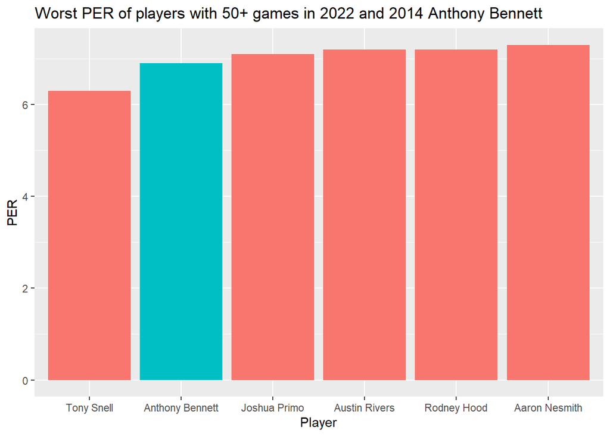

```r
shortened = rbind(players_2022[players_2022$countGames >= 50,], goat)
worst_per = shortened[order(shortened$ratioPER),]
bottom_6 = head(worst_per, 6)

ggplot(bottom_6, aes(reorder(namePlayer, ratioPER), ratioPER))+
  geom_bar(aes(fill=grepl("Anthony Bennett", namePlayer)), stat="identity") +
  theme(legend.position = "none") +
  ggtitle("Worst PER of players with 50+ games in 2022 and 2014 Anthony Bennett") +
  labs(y = "PER", x = "Player")
```

## True Shooting Percentage (TS%)

True Shooting Percentage takes shooting percentage, and weights it based on how valuable a shot is. This means you’re shooting percentage on 3s is increased and free throw percentage is weighed differently.

I’ll quickly skip over some repeat code now aside from the parts with changed stats.

```r
worst_tsp = shortened[order(shortened$pctTrueShooting),]
```

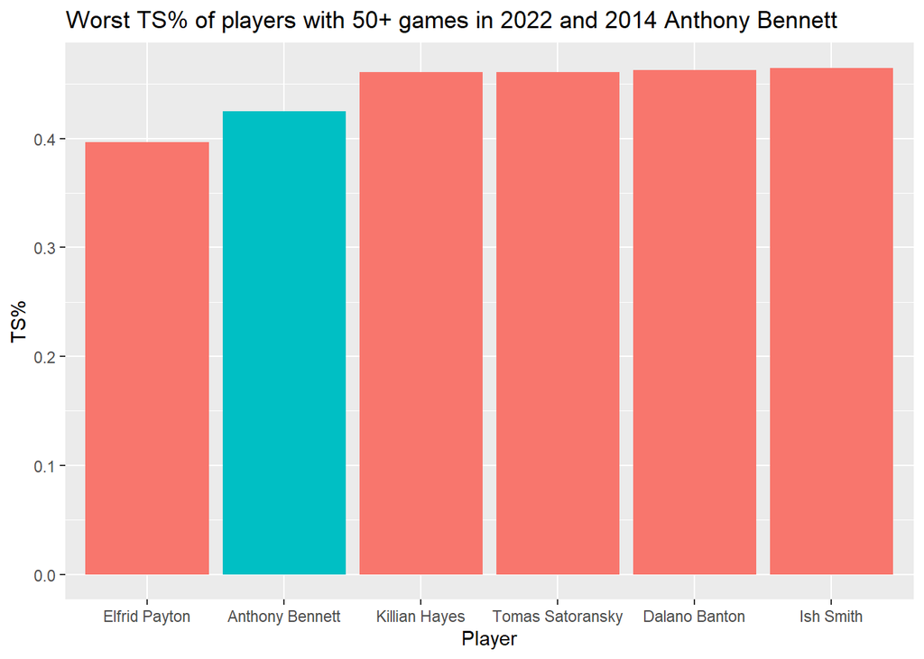

```r
ggplot(bottom_6, aes(reorder(namePlayer, pctTrueShooting), pctTrueShooting))+
  geom_bar(aes(fill=grepl("Anthony Bennett", namePlayer)), stat="identity") +
  theme(legend.position = "none") +
  ggtitle("Worst TS% of players with 50+ games in 2022 and 2014 Anthony Bennett") +
  labs(y = "TS%", x = "Player")
```

The only person below Anthony Bennett here is Elfrid Payton, who had a season shooting wise I didn’t even think was possible. As a guard, he shot 38.3% from the field, 22.2% from 3, and had a free throw percentage of 37.5%.

## Win Shares

Win shares takes a player’s value and puts it into the number of wins (or losses) contributed to a team.

```r
worst_ws = shortened[order(shortened$ratioWS),]
```

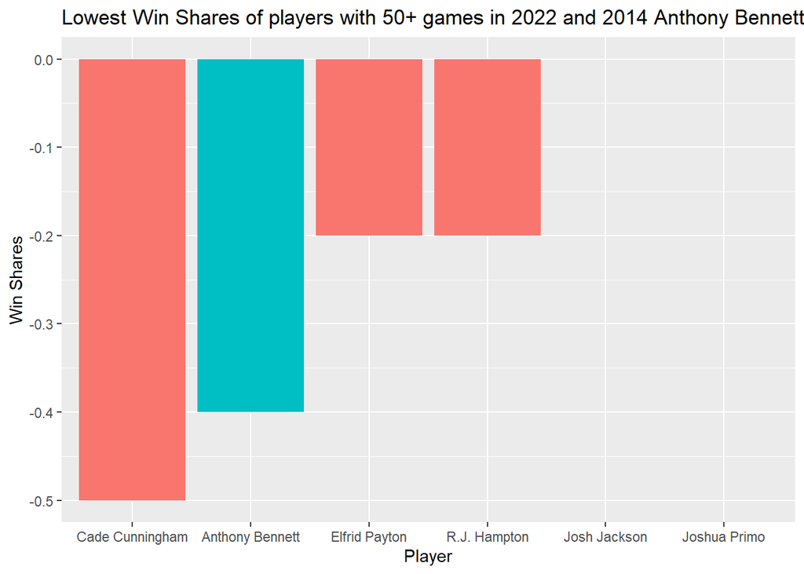

```r
ggplot(bottom_6, aes(reorder(namePlayer, ratioWS), ratioWS))+
  geom_bar(aes(fill=grepl("Anthony Bennett", namePlayer)), stat="identity") +
  theme(legend.position = "none") +
  ggtitle("Lowest Win Shares of players with 50+ games in 2022 and 2014 Anthony Bennett") +
  labs(y = "Win Shares", x = "Player")
```

The first thing is that having negative win shares is **really** bad. Like with negative win shares the team wins more when you’re not on the team. This also doesn’t have Jalen Suggs shown, who despite only playing 48 games had a whopping -1.6 win shares.

## Win Shares Per 48 Minutes

This just takes win shares and puts it on an equal per game basis to make up for players that play more.

```r
worst_wsper48 = shortened[order(shortened$ratioWSPer48),]
```

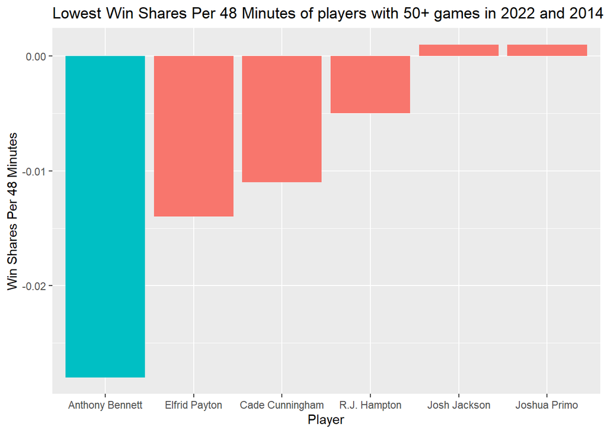

```r
ggplot(bottom_6, aes(reorder(namePlayer, ratioWSPer48), ratioWSPer48))+
  geom_bar(aes(fill=grepl("Anthony Bennett", namePlayer)), stat="identity") +
  theme(legend.position = "none") +
  ggtitle("Lowest Win Shares Per 48 Minutes of players with 50+ games in 2022 and 2014 Anthony Bennett") +
  labs(y = "Win Shares Per 48 Minutes", x = "Player")
```

Here we see Anthony Bennett truly shine. Even though he looks around the same as Cade Cunningham, a bright young NBA talent, putting it on a per-rate basis shows Bennett is by far the worst player in the NBA. Bennett is *twice* as bad as the next worst player, Elfrid Payton.

## Value Over Replacement Player (VORP)

VORP estimates the amount of box score points a player contributes to a team over a replacement level player, which is -2.0 VORP.

```r
worst_vorp = shortened[order(shortened$ratioVORP),]
```

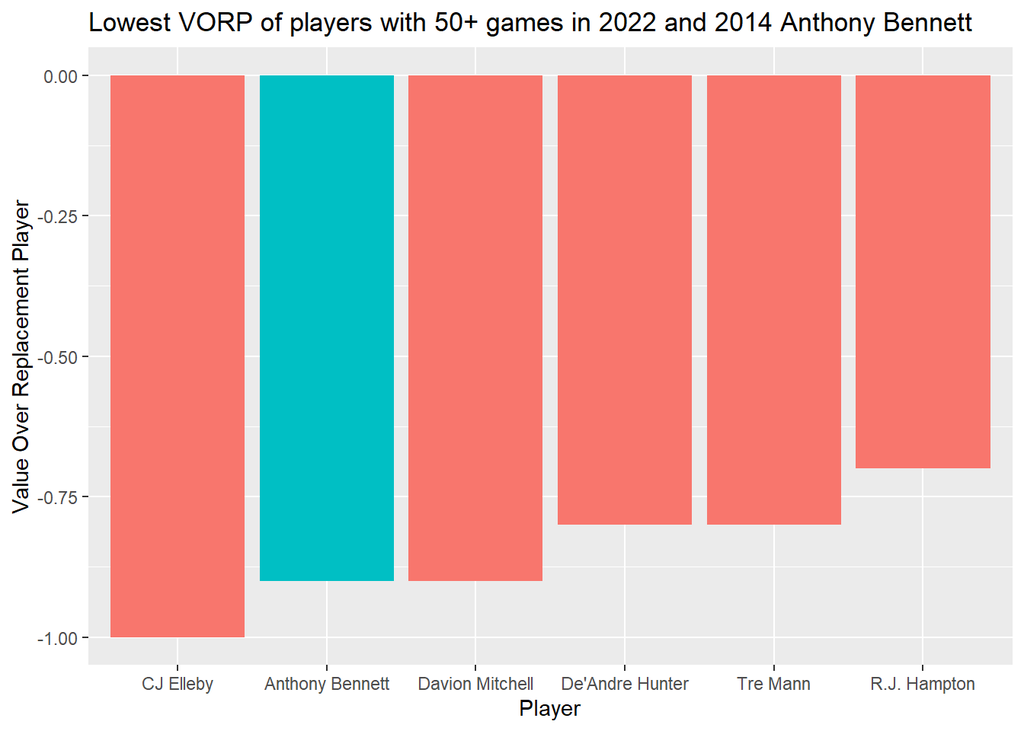

```r
ggplot(bottom_6, aes(reorder(namePlayer, ratioVORP), ratioVORP))+
  geom_bar(aes(fill=grepl("Anthony Bennett", namePlayer)), stat="identity") +
  theme(legend.position = "none") +
  ggtitle("Lowest VORP of players with 50+ games in 2022 and 2014 Anthony Bennett") +
  labs(y = "Value Over Replacement Player", x = "Player")
```

Luckily all players here are better than replacement level, but again Anthony Bennett is near the bottom of the bottom 6 players.

## Final Verdict

Anthony Bennett was in at best the bottom 2 of the main advanced stats in the NBA among players with at least 50 games, making him in my opinion easily the worst player in the NBA if he were in the 2021-2022 season. Due to this, I would consider the Anthony Bennett rule cruel and unusual punishment, but let’s see how each team fairs.

# How Winning Percentage For Each New Team Is Calculated

Before the fun we need to cover more nerd shit.

To calculate a team’s wins and losses, I’m totaling the win shares of the team’s top 9 most played players. To see what that’s like, here the chart of the best teams in the 2021-2022 season using top 9 players win shares:

```r
win_tots <- data.frame (
  Team = standing$nameTeam,
  Real_Wins = real_wins,
  Share_wins = calc_wins
)
kable(win_tots[order(-win_tots$Share_wins),])
```

|  | Team | Real_Wins | Share_wins |
| --- | --- | --- | --- |
| 2 | Boston Celtics | 51 | 55.1 |
| 24 | Phoenix Suns | 64 | 49.9 |
| 23 | Philadelphia 76ers | 51 | 49.5 |
| 29 | Utah Jazz | 49 | 47.9 |
| 7 | Dallas Mavericks | 52 | 47.8 |
| 16 | Miami Heat | 53 | 45.6 |
| 10 | Golden State Warriors | 53 | 45.3 |
| 15 | Memphis Grizzlies | 56 | 44.8 |
| 17 | Milwaukee Bucks | 51 | 44.3 |
| 4 | Charlotte Hornets | 43 | 44.3 |
| 28 | Toronto Raptors | 48 | 44.0 |
| 6 | Cleveland Cavaliers | 44 | 41.6 |
| 8 | Denver Nuggets | 48 | 39.9 |
| 18 | Minnesota Timberwolves | 46 | 39.8 |
| 1 | Atlanta Hawks | 43 | 39.2 |
| 3 | Brooklyn Nets | 44 | 38.7 |
| 27 | San Antonio Spurs | 34 | 37.0 |
| 20 | New York Knicks | 37 | 34.6 |
| 5 | Chicago Bulls | 46 | 34.5 |
| 30 | Washington Wizards | 35 | 33.9 |
| 13 | LA Clippers | 42 | 33.5 |
| 19 | New Orleans Pelicans | 36 | 32.6 |
| 26 | Sacramento Kings | 30 | 31.0 |
| 12 | Indiana Pacers | 25 | 28.1 |
| 14 | Los Angeles Lakers | 33 | 27.9 |
| 25 | Portland Trail Blazers | 27 | 24.1 |
| 11 | Houston Rockets | 20 | 21.5 |
| 9 | Detroit Pistons | 23 | 18.5 |
| 22 | Orlando Magic | 22 | 18.0 |
| 21 | Oklahoma City Thunder | 24 | 13.2 |

Although some teams get hit a bit harder and teams with injured stars get hit the most, the general idea is there for record as it’s generally plus or minus a couple wins.

# Rosters

If you don’t care to see the rosters (and read my own insight), just scroll ahead to the section on initial reactions.

Otherwise, here are all the rosters:

## Celtics

**PG: Terry Rozier** (Hornets)  
**SG: Marcus Smart** (Celtics)  
**SF: Max Strus** (Heat)  
**PF: Kyle Kuzma** (Wizards)  
**C: Grant Williams** (Celtics)  
6: Alperen Sengun (Rockets)  
7: Jeff Green (Nuggets)  
8: Payton Pritchard (Celtics)  
9: Damion Lee (Suns)

Extra Players:  
- Sam Hauser (Celtics)  
- Javonte Green (Bulls)

The Celtics get killed by no Brown or Tatum, and since they’ve been good for a while they’ve had high picks, which means not great young players aside from Kuzma.

Looking Statistically:

```r
celtics <- players_2022[grepl("BOS", players_2022$slugTeamsBREF),]
most_played_celtics <- tail(celtics[order(celtics$minutesTotals),], 9)
celtics_new = rbind(players_2022[grepl("Terry Rozier", players_2022$namePlayer),],
  players_2022[grepl("Marcus Smart", players_2022$namePlayer),],
  players_2022[grepl("Max Strus", players_2022$namePlayer),],
  players_2022[grepl("Kyle Kuzma", players_2022$namePlayer),],
  players_2022[grepl("Grant Williams", players_2022$namePlayer),],
  players_2022[grepl("Alperen Sengun", players_2022$namePlayer),],
  players_2022[grepl("Jeff Green", players_2022$namePlayer),],
  players_2022[grepl("Payton Pritchard", players_2022$namePlayer),],
  players_2022[grepl("Damion Lee", players_2022$namePlayer),])
wins_data_celtics = data.frame (
  Team = c("Original", "New", "Difference"),
  Wins = c(sum(most_played_celtics$ratioWS), sum(celtics_new$ratioWS), sum(celtics_new$ratioWS) - sum(most_played_celtics$ratioWS))
)
kable(wins_data_celtics)
```

| Team | Wins |
| --- | --- |
| Original | 55.1 |
| New | 34.0 |
| Difference | -21.1 |

You can see here the new Celtics is actually way worse, breaking it down by player, you see:

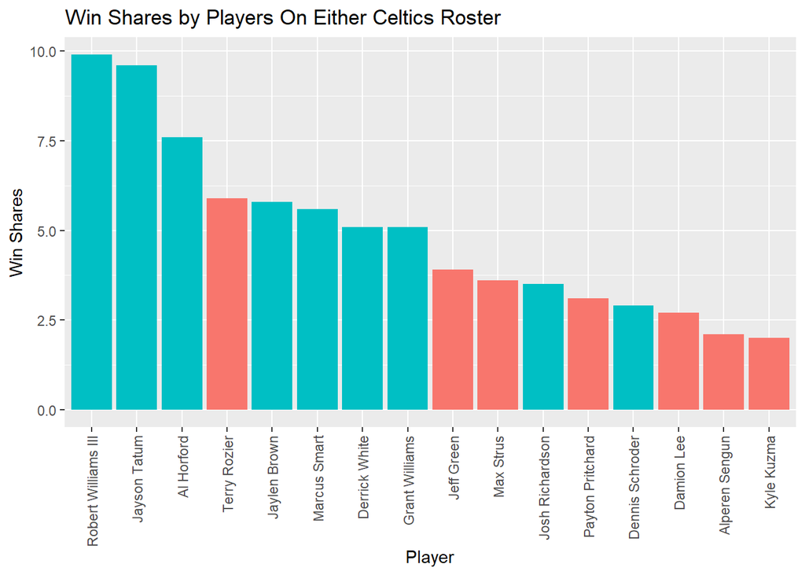

```r
combined = rbind(most_played_celtics, celtics_new)
combined = cbind(combined, original_team)
temp = data.table(combined)
combined = unique(temp, by = 'namePlayer')

ggplot(combined, aes(x=reorder(namePlayer, -ratioWS), y=ratioWS, fill=original_team)) +
  geom_bar(stat="identity") +
  theme(legend.position = "none", axis.text.x = element_text(angle = 90, vjust = 0.5, hjust=1)) +
  ggtitle("Win Shares by Players On Either Celtics Roster") +
  labs(y="Win Shares", x = "Player")
```

You can see here the biggest issue is top-heaviness. Kyle Kuzma was way less effective last year than I initially thought so they turn from a major contender to a potential tank team.

Final Verdict: Much worse.

## Bucks

**PG: Kevin Porter Jr.** (Rockets)  
**SG: Norman Powell** (Clippers)  
**SF: Desmond Bane** (Grizzlies)  
**PF: Jordan Nwora** (Bucks)  
**C: Giannis Antetokounmpo** (Bucks)  
6: Donte DiVincenzo (Warriors)  
7: MarJon Beauchamp (Bucks)  
8:  
9:

The Bucks become the first victim of missing players, but also show how aside from Giannis their core was mostly traded for. I’d also like to see KPJ try and be a number 3 option on a team, especially one with an MVP.

Digging in, we see:

```r
bucks <- players_2022[grepl("MIL", players_2022$slugTeamsBREF),]
most_played_bucks <- tail(bucks[order(bucks$minutesTotals),], 9)
```

```r
bucks_new = rbind(players_2022[grepl("Kevin Porter Jr", players_2022$namePlayer),],
                  players_2022[grepl("Norman Powell", players_2022$namePlayer),],
                  players_2022[grepl("Desmond Bane", players_2022$namePlayer),],
                  players_2022[grepl("Jordan Nwora", players_2022$namePlayer),],
                  players_2022[grepl("Giannis Antetokounmpo", players_2022$namePlayer),],
                  players_2022[grepl("Donte DiVincenzo", players_2022$namePlayer),],
                  temp,
                  goat, goat)
wins_data_bucks = data.frame (
  Team = c("Original", "New", "Difference"),
  Wins = c(sum(most_played_bucks$ratioWS), sum(bucks_new$ratioWS), sum(bucks_new$ratioWS) - sum(most_played_bucks$ratioWS)))

kable(wins_data_bucks)
```

| Team | Wins |
| --- | --- |
| Original | 44.30000 |
| New | 25.11111 |
| Difference | -19.18889 |

Here you see the Anthony Bennett effect come into full. This is not to mention this new roster has no depth at all aside from a new better number 2 option. Even with Desmond Bane Norman Powell or KPJ will not make up for Bobby Portis or Khris Middleton.

And you can see that with the player graph here:

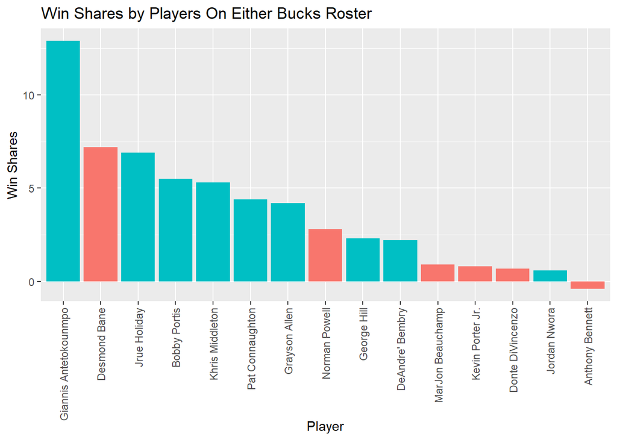

```r
combined = rbind(most_played_bucks, bucks_new)
combined = cbind(combined, original_team)
temp = data.table(combined)
combined = unique(temp, by = 'namePlayer')

ggplot(combined, aes(x=reorder(namePlayer, -ratioWS), y=ratioWS, fill=original_team)) +
  geom_bar(stat="identity") +
  theme(legend.position = "none", axis.text.x = element_text(angle = 90, vjust = 0.5, hjust=1)) +
  ggtitle("Win Shares by Players On Either Bucks Roster") +
  labs(y="Win Shares", x = "Player")
```

Final verdict: Worse but lots of potential.

## Cavaliers

**PG: Darius Garland** (Cavs)  
**SG: Andrew Wiggins** (Warriors)  
**SF: LeBron James** (Lakers)  
**PF: Jerami Grant** (Blazers)  
**C: Evan Mobley** (Cavs)  
6: Herb Jones (Pels)  
7: Tyus Jones (Grizzlies)  
8: Mo Wagner (Magic)  
9: Isaac Okoro (Cavs)

Extra Players:  
- Dean Wade (Cavs)  
- Lamar Stevens (Cavs)

This team would be damn good, especially since Wiggins, LeBron, and Mobley are all fairly versatile. You will also notice teams that went from playoff caliber to rebuild in the past 5 years.

This is the first case where wins could go either way, so lets see the stats:

```r
cavs <- players_2022[grepl("CLE", players_2022$slugTeamsBREF),]
most_played_cavs <- tail(cavs[order(cavs$minutesTotals),], 9)

cavs_new = rbind(players_2022[grepl("Darius Garland", players_2022$namePlayer),],
                    players_2022[grepl("Andrew Wiggins", players_2022$namePlayer),],
                    players_2022[grepl("LeBron James", players_2022$namePlayer),],
                    players_2022[grepl("Jerami Grant", players_2022$namePlayer),],
                    players_2022[grepl("Evan Mobley", players_2022$namePlayer),],
                    players_2022[grepl("Herbert Jones", players_2022$namePlayer),],
                    players_2022[grepl("Tyus Jones", players_2022$namePlayer),],
                    players_2022[grepl("Moritz Wagner", players_2022$namePlayer),],
                    players_2022[grepl("Isaac Okoro", players_2022$namePlayer),])

wins_data_cavs = data.frame (
  Team = c("Original", "New", "Difference"),
  Wins = c(sum(most_played_cavs$ratioWS), sum(cavs_new$ratioWS), sum(cavs_new$ratioWS) - sum(most_played_cavs$ratioWS)))

kable(wins_data_cavs)
```

| Team | Wins |
| --- | --- |
| Original | 41.6 |
| New | 43.1 |
| Difference | 1.5 |

Around the same, but a bit better, let’s see how depth plays into this new roster:

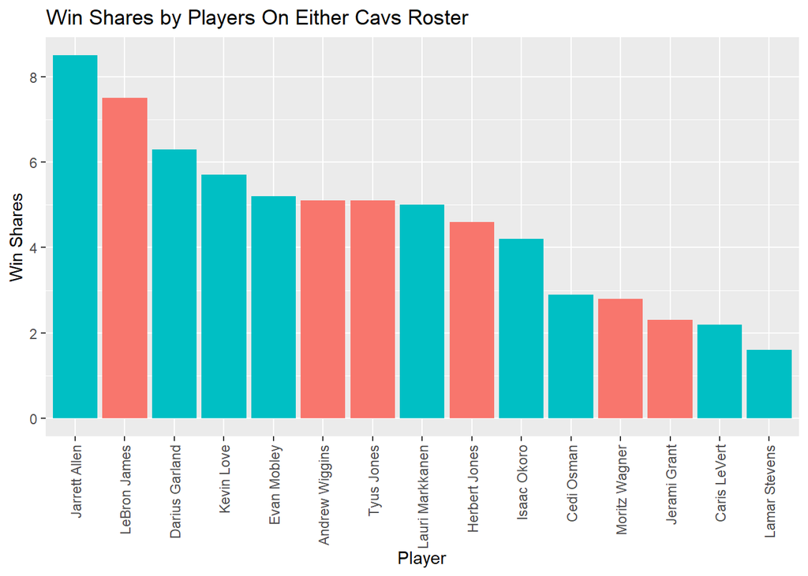

```r
combined = rbind(most_played_cavs, cavs_new)
combined = cbind(combined, original_team)
temp = data.table(combined)
combined = unique(temp, by = 'namePlayer')

ggplot(combined, aes(x=reorder(namePlayer, -ratioWS), y=ratioWS, fill=original_team)) +
  geom_bar(stat="identity") +
  theme(legend.position = "none", axis.text.x = element_text(angle = 90, vjust = 0.5, hjust=1)) +
  ggtitle("Win Shares by Players On Either Cavs Roster") +
  labs(y="Win Shares", x = "Player")
```

Although Lebron and Wiggins add a lot of value, no Jarrett Allen or K Love does some damage to their wins, as Allen was suprisingly valuable last year (keep a look out for when he pops up later).

Final verdict: Better especially since there’s the LeBron effect.

## Nets

**PG: Damian Lillard** (Blazers)  
**SG: Collin Sexton** (Jazz)  
**SF: Jaylen Brown** (Celtics)  
**PF: Draymond Green** (Warriors)  
**C: Brook Lopez** (Bucks)  
6: Markelle Fultz (Magic)  
7: Mason Plumlee (Hornets)  
8: Aleksej Pokusevski (Thunder)  
9: Talen Horton-Tucker (Jazz)

Extra Players:  
- Pat Connaughton (Bucks)  
- Cam Thomas (Nets)  
- Jordan McLaughlin (Wolves)  
- Tari Eason (Rockets)

First things about the Tatum-Fultz-Fox trade and how it works: - Pick 1 was from Nets -> Boston, went to Philly - Pick 3 was from Sacramento, went to Boston (!!!) - Pick 5 was from Philly, went to Sacramento

There’s a bunch of other random pieces to it but that’s the basic gist, but onto my review of this team.

I seriously have no clue what the Nets are doing. Maybe KD was right. This is not to mention if they just kept their picks they probably draft Tatum instead of Fultz and have a core or Lillard Brown Tatum Draymond and Brook Lopez that would easily win multiple chips.

Let’s see if the stats agree:

```r
nets <- players_2022[grepl("BRK", players_2022$slugTeamsBREF),]
most_played_nets <- tail(nets[order(nets$minutesTotals),], 9)

nets_new = rbind(players_2022[grepl("Damian Lillard", players_2022$namePlayer),],
                    players_2022[grepl("Collin Sexton", players_2022$namePlayer),],
                    players_2022[grepl("Jaylen Brown", players_2022$namePlayer),],
                    players_2022[grepl("Draymond Green", players_2022$namePlayer),],
                    players_2022[grepl("Brook Lopez", players_2022$namePlayer),],
                    players_2022[grepl("Markelle Fultz", players_2022$namePlayer),],
                    players_2022[grepl("Mason Plumlee", players_2022$namePlayer),],
                    players_2022[grepl("Aleksej Pokusevski", players_2022$namePlayer),],
                    players_2022[grepl("Talen Horton-Tucker", players_2022$namePlayer),])

wins_data_nets = data.frame (
  Team = c("Original", "New", "Difference"),
  Wins = c(sum(most_played_nets$ratioWS), sum(nets_new$ratioWS), sum(nets_new$ratioWS) - sum(most_played_nets$ratioWS)))

kable(wins_data_nets)
```

| Team | Wins |
| --- | --- |
| Original | 38.7 |
| New | 18.3 |
| Difference | -20.4 |

?????????

WHAT

It honestly makes zero sense until you look at per-player value:

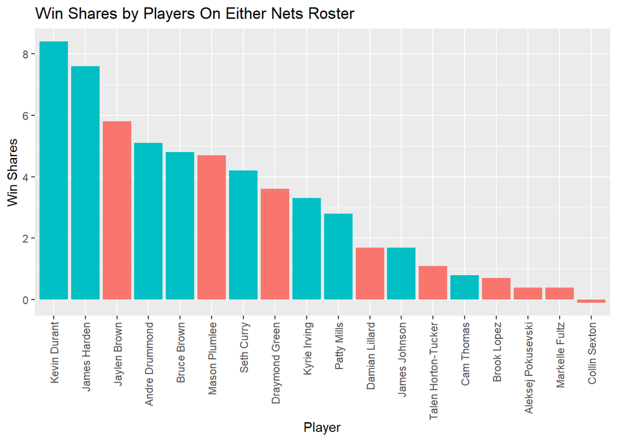

```r
combined = rbind(most_played_nets, nets_new)
combined = cbind(combined, original_team)
temp = data.table(combined)
combined = unique(temp, by = 'namePlayer')

ggplot(combined, aes(x=reorder(namePlayer, -ratioWS), y=ratioWS, fill=original_team)) +
  geom_bar(stat="identity") +
  theme(legend.position = "none", axis.text.x = element_text(angle = 90, vjust = 0.5, hjust=1)) +
  ggtitle("Win Shares by Players On Either Nets Roster") +
  labs(y="Win Shares", x = "Player")
```

You’re losing KD and Harden with their great seasons, while Sexton and Lillard were hurt a lot so they couldn’t do much to compensate. Does this start to point out flaws with my system: yes, but is this a study primarily on last year: also yes.

Final verdict: Given Harden is gone I’d say *slightly* worse

## 76ers

**PG: De’Aaron Fox** (Kings)  
**SG: Jrue Holiday** (Bucks)  
**SF: Ben Simmons** (Nets)  
**PF: Nikola Vucevic** (Bulls)  
**C: Joel Embiid** (76ers)  
6: Christian Wood (Mavs)  
7: Andre Iguodala (Warriors)  
8: Saddiq Bey (Pistons)  
9: TJ McConnell (Pacers)

Extra Players:  
- Thad Young (Raptors)  
- Haywood Highsmith (Heat)  
- David Roddy (Grizzlies)  
- Landry Shamet (Suns)

I don’t know whether to say trust the process or the process failed. On one hand, this team seems really good, but on the other hand only 2 are from the process, as Noel and Okafor (or MCW if you wanna go really deep) aren’t even in the league anymore.

Let’s see what the numbers say, especially after the Nets:

```r
sixers <- players_2022[grepl("PHI", players_2022$slugTeamsBREF),]
most_played_sixers <- tail(sixers[order(sixers$minutesTotals),], 9)

temp = players_2023[grepl("Ben Simmons", players_2023$namePlayer),]
temp[1,]$ratioWS = temp[1,]$ratioWS * (82 / temp[1,]$countGames)

sixers_new = rbind(players_2022[grepl("De'Aaron Fox", players_2022$namePlayer),],
                    players_2022[grepl("Jrue Holiday", players_2022$namePlayer),],
                    temp,
                    players_2022[grepl("Nikola Vucevic", players_2022$namePlayer),],
                    players_2022[grepl("Joel Embiid", players_2022$namePlayer),],
                    players_2022[grepl("Christian Wood", players_2022$namePlayer),],
                    players_2022[grepl("Andre Iguodala", players_2022$namePlayer),],
                    players_2022[grepl("Saddiq Bey", players_2022$namePlayer),],
                    players_2022[grepl("T.J. McConnell", players_2022$namePlayer),])

wins_data_sixers = data.frame (
  Team = c("Original", "New", "Difference"),
  Wins = c(sum(most_played_sixers$ratioWS), sum(sixers_new$ratioWS), sum(sixers_new$ratioWS) - sum(most_played_sixers$ratioWS)))

kable(wins_data_sixers)
```

| Team | Wins |
| --- | --- |
| Original | 49.500000 |
| New | 43.557143 |
| Difference | -5.942857 |

To start, I wanted to include that I had to treat Ben Simmons stats like a rookie where I just projected his 2023 season over 82 games since he missed **all** of last year. But aside from that the sixers are relatively the same:

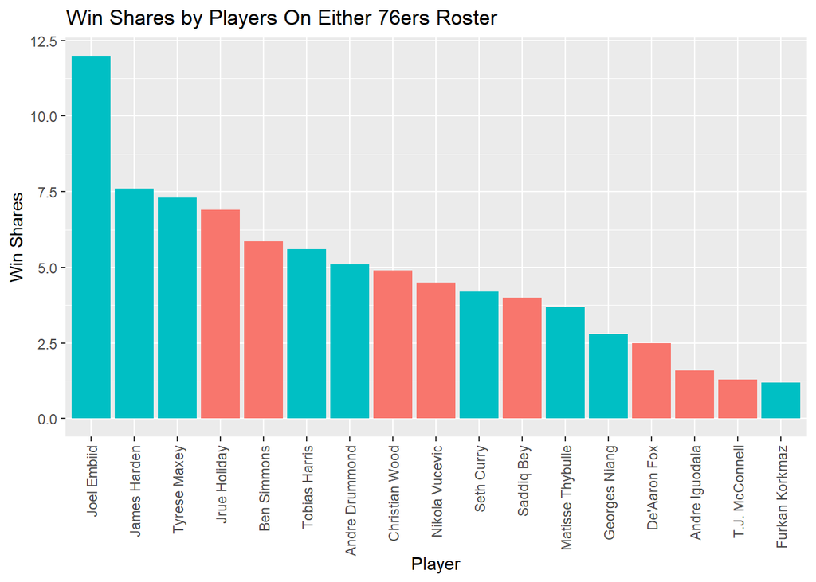

```r
combined = rbind(most_played_sixers, sixers_new)
combined = cbind(combined, original_team)
temp = data.table(combined)
combined = unique(temp, by = 'namePlayer')

ggplot(combined, aes(x=reorder(namePlayer, -ratioWS), y=ratioWS, fill=original_team)) +
  geom_bar(stat="identity") +
  theme(legend.position = "none", axis.text.x = element_text(angle = 90, vjust = 0.5, hjust=1)) +
  ggtitle("Win Shares by Players On Either 76ers Roster") +
  labs(y="Win Shares", x = "Player")
```

No Maxie or Harden but the added production of Jrue and (2023) Ben help a bit. De’Aaron Fox was also surprisingly inefficient last year, even compared to his past seasons.

Final verdict: Slightly worse. Even De’Aaron improving doesn’t make up for no Harden/Maxey and you still have to deal with Ben.

## Knicks

**PG: Jamal Murray** (Nuggets)  
**SG: RJ Barrett** (Knicks)  
**SF: Gordon Hayward** (Hornets)  
**PF: Kristaps Porzingis** (Wizards)  
**C: Nic Claxton** (Nets)  
6: Tim Hardaway Jr. (Mavs)  
7: Obi Toppin (Knicks)  
8: Luke Kornet (Celtics)  
9:

I have no clue what the Knicks do. Like this team has 3 glass sculptures and prime Anthony Bennett and it’s still better than the current Knicks with the mid 3 (well at least what I think, we’ll see what the numbers say).

```r
knicks <- players_2022[grepl("NYK", players_2022$slugTeamsBREF),]
most_played_knicks <- tail(knicks[order(knicks$minutesTotals),], 9)
```

```r
knicks_new = rbind(players_2022[grepl("RJ Barrett", players_2022$namePlayer),],
                    players_2022[grepl("Gordon Hayward", players_2022$namePlayer),],
                    temp,
                    players_2022[grepl("Kristaps Porzingis", players_2022$namePlayer),],
                    players_2022[grepl("Nic Claxton", players_2022$namePlayer),],
                    players_2022[grepl("Tim Hardaway Jr.", players_2022$namePlayer),],
                    players_2022[grepl("Obi Toppin", players_2022$namePlayer),],
                    players_2022[grepl("Luke Kornet", players_2022$namePlayer),],
                    goat)

wins_data_knicks = data.frame (
  Team = c("Original", "New", "Difference"),
  Wins = c(sum(most_played_knicks$ratioWS), sum(knicks_new$ratioWS), sum(knicks_new$ratioWS) - sum(most_played_knicks$ratioWS)))

kable(wins_data_knicks)
```

| Team | Wins |
| --- | --- |
| Original | 34.60 |
| New | 23.38 |
| Difference | -11.22 |

Yeah… when you’re glass players miss a lot of time and you have an empty spot you’re going to eat a lot more losses, you can see it here too:

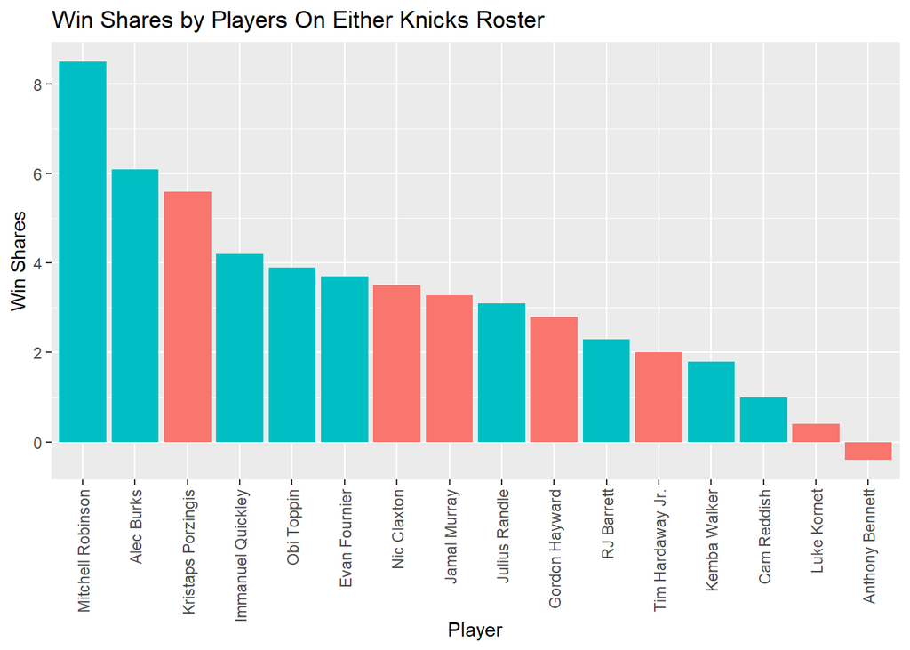

```r
combined = rbind(most_played_knicks, knicks_new)
combined = cbind(combined, original_team)
temp = data.table(combined)
combined = unique(temp, by = 'namePlayer')

ggplot(combined, aes(x=reorder(namePlayer, -ratioWS), y=ratioWS, fill=original_team)) +
  geom_bar(stat="identity") +
  theme(legend.position = "none", axis.text.x = element_text(angle = 90, vjust = 0.5, hjust=1)) +
  ggtitle("Win Shares by Players On Either Knicks Roster") +
  labs(y="Win Shares", x = "Player")
```

Final verdict: Same I guess Knicks are mid either way.

## Hawks

**PG: Luka Doncic** (Mavs)  
**SG: Dennis Schroder** (Lakers)  
**SF: Kelly Oubre Jr.** (Hornets)  
**PF: John Collins** (Hawks)  
**C: Al Horford** (Celtics)  
6: AJ Griffin (Hawks)  
7: Onyeka Okongwu (Hawks)  
8: Theo Maledon (Hornets) 9:

No clue what to say for the Hawks. On one hand, Luka. On the other, negative depth. Luka may have to carry this team harder than the Mavericks somehow.

Let’s see if Luka covers the gap:

```r
hawks <- players_2022[grepl("ATL", players_2022$slugTeamsBREF),]
most_played_hawks <- tail(hawks[order(hawks$minutesTotals),], 9)
```

```r
hawks_new = rbind(players_2022[grepl("Luka Doncic", players_2022$namePlayer),],
                    players_2022[grepl("Dennis Schroder", players_2022$namePlayer),],
                    temp,
                    players_2022[grepl("Kelly Oubre Jr.", players_2022$namePlayer),],
                    players_2022[grepl("John Collins", players_2022$namePlayer),],
                    players_2022[grepl("Al Horford", players_2022$namePlayer),],
                    players_2022[grepl("Onyeka Okongwu", players_2022$namePlayer),],
                    players_2022[grepl("Theo Maledon", players_2022$namePlayer),],
                    goat)

wins_data_hawks = data.frame (
  Team = c("Original", "New", "Difference"),
  Wins = c(sum(most_played_hawks$ratioWS), sum(hawks_new$ratioWS), sum(hawks_new$ratioWS) - sum(most_played_hawks$ratioWS)))

kable(wins_data_hawks)
```

| Team | Wins |
| --- | --- |
| Original | 39.200000 |
| New | 33.438462 |
| Difference | -5.761539 |

Slightly worse, let’s see how the depth holds on a per-player level:

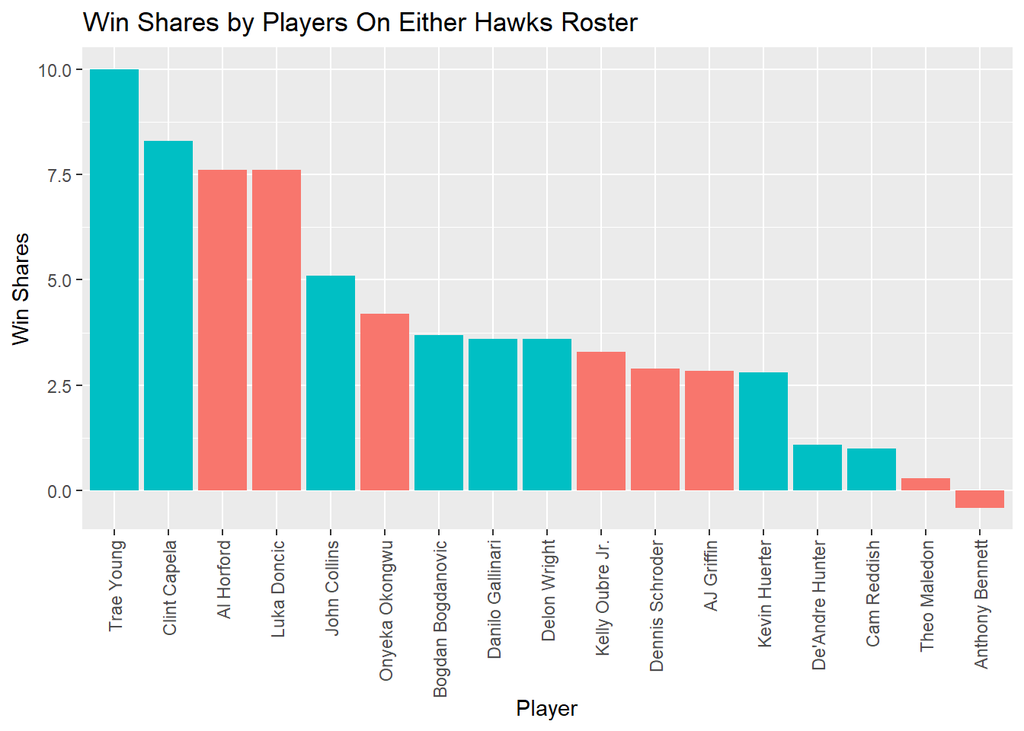

```r
combined = rbind(most_played_hawks, hawks_new)
combined = cbind(combined, original_team)
temp = data.table(combined)
combined = unique(temp, by = 'namePlayer')

ggplot(combined, aes(x=reorder(namePlayer, -ratioWS), y=ratioWS, fill=original_team)) +
  geom_bar(stat="identity") +
  theme(legend.position = "none", axis.text.x = element_text(angle = 90, vjust = 0.5, hjust=1)) +
  ggtitle("Win Shares by Players On Either Hawks Roster") +
  labs(y="Win Shares", x = "Player")
```

It wasn’t the depth. Trae was just more valuable that Luka. That and Al Horford is a slight downgrade to Capela. That plus slightly worse depth causes the small gap.

Final verdict: Worse? Luka seems undervalued but team still worse if Trae and Luka swapped WS.

## Pacers

**PG: Bennedict Mathurin** (Pacers)  
**SG: Paul George** (Clippers)  
**SF: Kawhi Leonard** (Clippers)  
**PF: Bogdan Bogdanovic** (Hawks)  
**C: Myles Turner** (Pacers)  
6: Caris LeVert (Cavs)  
7: Georges Niang (76ers)  
8: RJ Hampton (Magic)  
9: Chris Duarte (Pacers)

Extra Players:  
- Aaron Holiday (Hawks)  
- Davis Bertans (Mavs)

The Pacers somehow would be the Clippers but way better if they weren’t silly.

The stats will probably say they’re bad though given the two stars:

```r
pacers <- players_2022[grepl("IND", players_2022$slugTeamsBREF),]
most_played_pacers <- tail(pacers[order(pacers$minutesTotals),], 9)
```

```r
pacers_new = rbind(players_2022[grepl("Paul George", players_2022$namePlayer),],
                    temp,
                    temp2,
                    players_2022[grepl("Bogdan Bogdanovic", players_2022$namePlayer),],
                    players_2022[grepl("Myles Turner", players_2022$namePlayer),],
                    players_2022[grepl("Caris LeVert", players_2022$namePlayer),],
                    players_2022[grepl("Georges Niang", players_2022$namePlayer),],
                    players_2022[grepl("R.J. Hampton", players_2022$namePlayer),],
                    players_2022[grepl("Chris Duarte", players_2022$namePlayer),])

wins_data_pacers = data.frame (
  Team = c("Original", "New", "Difference"),
  Wins = c(sum(most_played_pacers$ratioWS), sum(pacers_new$ratioWS), sum(pacers_new$ratioWS) - sum(most_played_pacers$ratioWS)))

kable(wins_data_pacers)
```

| Team | Wins |
| --- | --- |
| Original | 28.100000 |
| New | 20.917889 |
| Difference | -7.182111 |

And… yup. Even with the addition of Ben Mathurin that shouldn’t be an addition, they’re worse.

Looking at players you find the suspected culprits:

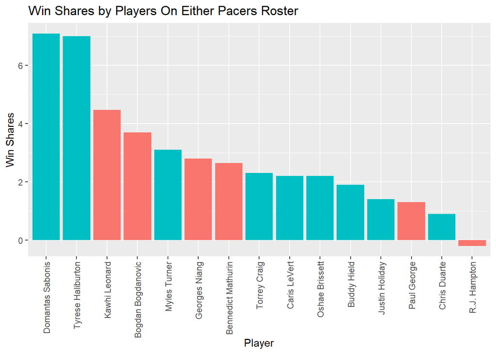

```r
combined = rbind(most_played_pacers, pacers_new)
combined = cbind(combined, original_team)
temp = data.table(combined)
combined = unique(temp, by = 'namePlayer')

ggplot(combined, aes(x=reorder(namePlayer, -ratioWS), y=ratioWS, fill=original_team)) +
  geom_bar(stat="identity") +
  theme(legend.position = "none", axis.text.x = element_text(angle = 90, vjust = 0.5, hjust=1)) +
  ggtitle("Win Shares by Players On Either Pacers Roster") +
  labs(y="Win Shares", x = "Player")
```

This is including Kawhi’s “Healthy” 2023 season by the way. This just shows Kawhi hasn’t been Kawhi since he’s carried a whole country on his back. PG being hurt most of last year and Sabonis and Tyrese being very good don’t help either.

Final verdict: Better I guess. I’ll always be a huge Clippers hater so I’ll say Kawhi and PG aren’t a sensational duo but it’s still better than the current Pacers. Shout outs to Tyrese for making think about this for a second though.

## Raptors

**PG: Fred VanVleet** (Raptors)  
**SG: Keldon Johnson** (Spurs)  
**SF: DeMar DeRozan** (Bulls)  
**PF: Scottie Barnes** (Raptors)  
**C: Pascal Siakam** (Raptors)  
6: Jonas Valanciunas (Pels)  
7: Steven Adams (Grizzlies)  
8: PJ Tucker (76ers)  
9: Goran Dragic (Bulls)

Extra Players:  
- Delon Wright (Wizards)  
- Terrence Ross (Magic)  
- Terence Davis (Kings)

The Raptors going from eternal playoff losses to chip to top 5 pick to eternal playoff losses makes their team loaded. I would actually really wanna see this team.

Let’s see if the stats agree:

```r
raptors <- players_2022[grepl("TOR", players_2022$slugTeamsBREF),]
most_played_raptors <- tail(raptors[order(raptors$minutesTotals),], 9)

raptors_new = rbind(players_2022[grepl("Fred VanVleet", players_2022$namePlayer),],
                    players_2022[grepl("Keldon Johnson", players_2022$namePlayer),],
                    players_2022[grepl("DeMar DeRozan", players_2022$namePlayer),],
                    players_2022[grepl("Scottie Barnes", players_2022$namePlayer),],
                    players_2022[grepl("Pascal Siakam", players_2022$namePlayer),],
                    players_2022[grepl("Jonas Valanciunas", players_2022$namePlayer),],
                    players_2022[grepl("Steven Adams", players_2022$namePlayer),],
                    players_2022[grepl("P.J. Tucker", players_2022$namePlayer),],
                    players_2022[grepl("Goran Dragic", players_2022$namePlayer),])

wins_data_raptors = data.frame (
  Team = c("Original", "New", "Difference"),
  Wins = c(sum(most_played_raptors$ratioWS), sum(raptors_new$ratioWS), sum(raptors_new$ratioWS) - sum(most_played_raptors$ratioWS)))

kable(wins_data_raptors)
```

| Team | Wins |
| --- | --- |
| Original | 44.0 |
| New | 54.6 |
| Difference | 10.6 |

Yeah, easily the best team so far, and looking at the per-player shares you can see why:

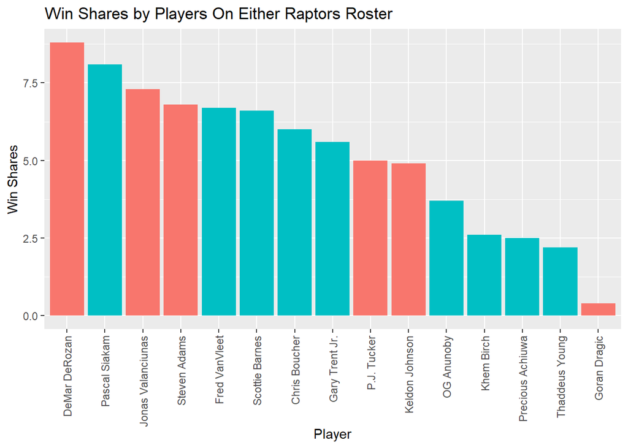

```r
combined = rbind(most_played_raptors, raptors_new)
combined = cbind(combined, original_team)
temp = data.table(combined)
combined = unique(temp, by = 'namePlayer')

ggplot(combined, aes(x=reorder(namePlayer, -ratioWS), y=ratioWS, fill=original_team)) +
  geom_bar(stat="identity") +
  theme(legend.position = "none", axis.text.x = element_text(angle = 90, vjust = 0.5, hjust=1)) +
  ggtitle("Win Shares by Players On Either Raptors Roster") +
  labs(y="Win Shares", x = "Player")
```

The Raptors barely lose anything (Chris Boucher, Gary Trent Jr ig), but gain a ton from DeMarr, Jonas, Steven Adams, and PJ Tucker where it more than makes up for it.

Final verdict: Far and away better. I guess getting that ring was worth it though.

## Heat

**PG: Tyler Herro** (Heat)  
**SG: Jaylen Nowell** (Wolves)  
**SF: Josh Richardson** (Spurs)  
**PF: Precious Achiuwa** (Raptors)  
**C: Bam Adebayo** (Heat)  
6: De’Anthony Melton (76ers)  
7: Justise Winslow (Blazers)  
8: Tre Mann (Thunder)  
9: Duncan Robinson (Heat)

Extra Players:  
- Orlando Robinson (Heat)

The Heat are carried by trades. I honestly believe this team would have to tank this year. Running Justice Winslow as your 7th man and Duncan Robinson in the 9 man rotation should be illegal.

Let’s see if the stats agree (they will)

```r
heat <- players_2022[grepl("MIA", players_2022$slugTeamsBREF),]
most_played_heat <- tail(heat[order(heat$minutesTotals),], 9)

heat_new = rbind(players_2022[grepl("Tyler Herro", players_2022$namePlayer),],
                    players_2022[grepl("Jaylen Nowell", players_2022$namePlayer),],
                    players_2022[grepl("Josh Richardson", players_2022$namePlayer),],
                    players_2022[grepl("Precious Achiuwa", players_2022$namePlayer),],
                    players_2022[grepl("Bam Adebayo", players_2022$namePlayer),],
                    players_2022[grepl("De'Anthony Melton", players_2022$namePlayer),],
                    players_2022[grepl("Justise Winslow", players_2022$namePlayer),],
                    players_2022[grepl("Tre Mann", players_2022$namePlayer),],
                    players_2022[grepl("Duncan Robinson", players_2022$namePlayer),])

wins_data_heat = data.frame (
  Team = c("Original", "New", "Difference"),
  Wins = c(sum(most_played_heat$ratioWS), sum(heat_new$ratioWS), sum(heat_new$ratioWS) - sum(most_played_heat$ratioWS)))

kable(wins_data_heat)
```

| Team | Wins |
| --- | --- |
| Original | 45.6 |
| New | 28.3 |
| Difference | -17.3 |

Yeah… Surprisingly not the biggest downgrade of teams but still a huge dropoff.

Looking at per-players you really see it:

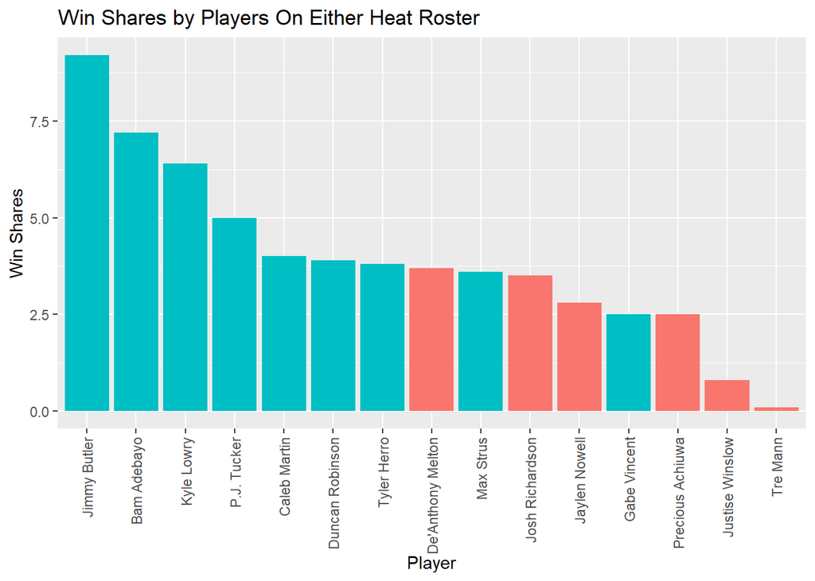

```r
combined = rbind(most_played_heat, heat_new)
combined = cbind(combined, original_team)
temp = data.table(combined)
combined = unique(temp, by = 'namePlayer')

ggplot(combined, aes(x=reorder(namePlayer, -ratioWS), y=ratioWS, fill=original_team)) +
  geom_bar(stat="identity") +
  theme(legend.position = "none", axis.text.x = element_text(angle = 90, vjust = 0.5, hjust=1)) +
  ggtitle("Win Shares by Players On Either Heat Roster") +
  labs(y="Win Shares", x = "Player")
```

Every new player for the Heat is near the bottom of the wins shares chart. I made fun of Duncan Robinson but he somehow has more win shares than every new player on the team.

Final verdict: Much worse. Stats say they’re way worse and the eye test definitely agrees.

## Bulls

**PG: Ayo Dosunmu** (Bulls)  
**SG: Jimmy Butler** (Heat)  
**SF: Franz Wagner** (Magic)  
**PF: Wendell Carter Jr.** (Magic)  
**C: Mitchell Robinson** (Knicks)  
6: Bobby Portis (Bucks)  
7: Patrick Williams (Bulls)  
8: Gary Harris (Magic)  
9: Derrick Rose (Knicks)

Extra Players:  
- Coby White (Bulls)  
- Danny Green (Grizzlies)

Somehow the Bulls stay around equally good despite no DeMarr/LaVine/Lonzo. Maybe it’s because they get Jimmy Butler back and redoing the awful Vuc trade also helps.

Stats might disagree though so let’s see:

```r
bulls <- players_2022[grepl("CHI", players_2022$slugTeamsBREF),]
most_played_bulls <- tail(bulls[order(bulls$minutesTotals),], 9)

bulls_new = rbind(players_2022[grepl("Ayo Dosunmu", players_2022$namePlayer),],
                    players_2022[grepl("Jimmy Butler", players_2022$namePlayer),],
                    players_2022[grepl("Franz Wagner", players_2022$namePlayer),],
                    players_2022[grepl("Wendell Carter Jr.", players_2022$namePlayer),],
                    players_2022[grepl("Mitchell Robinson", players_2022$namePlayer),],
                    players_2022[grepl("Bobby Portis", players_2022$namePlayer),],
                    players_2022[grepl("Patrick Williams", players_2022$namePlayer),],
                    players_2022[grepl("Gary Harris", players_2022$namePlayer),],
                    players_2022[grepl("Derrick Rose", players_2022$namePlayer),])

wins_data_bulls = data.frame (
  Team = c("Original", "New", "Difference"),
  Wins = c(sum(most_played_bulls$ratioWS), sum(bulls_new$ratioWS), sum(bulls_new$ratioWS) - sum(most_played_bulls$ratioWS)))

kable(wins_data_bulls)
```

| Team | Wins |
| --- | --- |
| Original | 34.5 |
| New | 39.7 |
| Difference | 5.2 |

Yeah, they do. As seen earlier Mitchell Robinson has a lot of value, so Mitchell + Jimmy more than makes up for no DeMarr/LaVine, which you can see in the per-player chart:

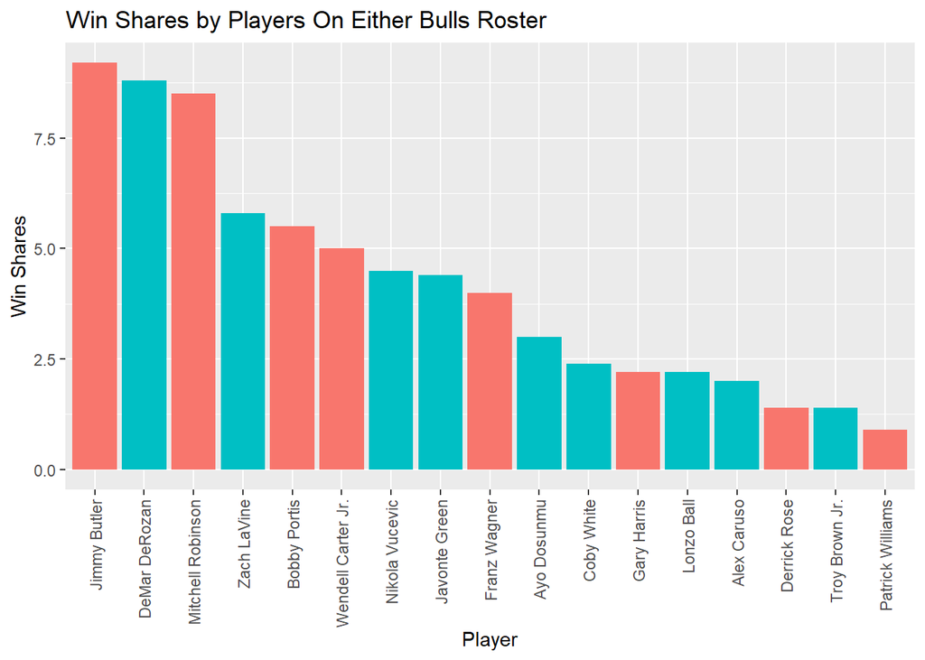

```r
combined = rbind(most_played_bulls, bulls_new)
combined = cbind(combined, original_team)
temp = data.table(combined)
combined = unique(temp, by = 'namePlayer')

ggplot(combined, aes(x=reorder(namePlayer, -ratioWS), y=ratioWS, fill=original_team)) +
  geom_bar(stat="identity") +
  theme(legend.position = "none", axis.text.x = element_text(angle = 90, vjust = 0.5, hjust=1)) +
  ggtitle("Win Shares by Players On Either Bulls Roster") +
  labs(y="Win Shares", x = "Player")
```

Jimmy and Mitchell end up being number 1 and 3 on the chart, not to mention Bobby Portis and Wendell Carter added much needed depth over Vuc. Kinda says something about how bad that trade was…

## Wizards

**PG: John Wall** (Clippers)  
**SG: Bradley Beal** (Wizards)  
**SF: Jordan Clarkson** (Jazz)  
**PF: Rui Hachimura** (Wizards)  
**C: Jarrett Allen** (Cavs)  
6: Corey Kispert (Wizards)  
7: Deni Avdija (Wizards)  
8: Otto Porter Jr. (Raptors)  
9: JaVale McGee (Mavs)

Extra Players:  
- Edmond Summer (Nets)  
- Danuel House Jr. (76ers)  
- Jordan Goodwin (Wizards)  
- Troy Brown Jr. (Lakers)

Just like the current Wizards, this feels like the most mid team of all time. Jarrett Allen and Bradley Beal are nice but your next best options being Jordan Clarkson and prehistoric John Wall is not great.

Honestly I kinda have no clue what the stats will say so let’s see:

```r
wizards <- players_2022[grepl("WAS", players_2022$slugTeamsBREF),]
most_played_wizards <- tail(wizards[order(wizards$minutesTotals),], 9)
```

```r
wizards_new = rbind(temp,
                    players_2022[grepl("Bradley Beal", players_2022$namePlayer),],
                    players_2022[grepl("Jordan Clarkson", players_2022$namePlayer),],
                    players_2022[grepl("Rui Hachimura", players_2022$namePlayer),],
                    players_2022[grepl("Jarrett Allen", players_2022$namePlayer),],
                    players_2022[grepl("Corey Kispert", players_2022$namePlayer),],
                    players_2022[grepl("Deni Avdija", players_2022$namePlayer),],
                    players_2022[grepl("Otto Porter Jr.", players_2022$namePlayer),],
                    players_2022[grepl("JaVale McGee", players_2022$namePlayer),])

wins_data_wizards = data.frame (
  Team = c("Original", "New", "Difference"),
  Wins = c(sum(most_played_wizards$ratioWS), sum(wizards_new$ratioWS), sum(wizards_new$ratioWS) - sum(most_played_wizards$ratioWS)))

kable(wins_data_wizards)
```

| Team | Wins |
| --- | --- |
| Original | 33.900 |
| New | 31.268 |
| Difference | -2.632 |

Around the same. Not really sure why but it’s probably the lack of depth with the new roster even with the addition of Allen.

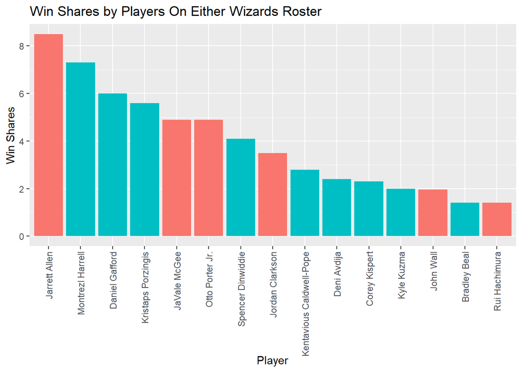

```r
combined = rbind(most_played_wizards, wizards_new)
combined = cbind(combined, original_team)
temp = data.table(combined)
combined = unique(temp, by = 'namePlayer')

ggplot(combined, aes(x=reorder(namePlayer, -ratioWS), y=ratioWS, fill=original_team)) +
  geom_bar(stat="identity") +
  theme(legend.position = "none", axis.text.x = element_text(angle = 90, vjust = 0.5, hjust=1)) +
  ggtitle("Win Shares by Players On Either Wizards Roster") +
  labs(y="Win Shares", x = "Player")
```

Yeah. Allen was the most valuable player here but Harrell, Gafford, and Porzingis were all surprisingly valuable.

## Magic

**PG: Jalen Suggs** (Magic)  
**SG: Victor Oladipo** (Heat)  
**SF: Aaron Gordon** (Nuggets)  
**PF: Paolo Banchero** (Magic)  
**C: Domantas Sabonis** (Kings)  
6: Jonathan Isaac (Magic)  
7: Cole Anthony (Magic)  
8: Joe Harris (Nets)  
9: Mo Bamba (Magic)

Extra Players:  
- Chuma Okeke (Magic)  
- Caleb Houston (Magic)

I honestly don’t know how to feel about this. The frontcourt of Gordon, Paolo, and Sabonis seems good but not amazing and the backcourt of bust Suggs and always injured Dipo is terrible. Feels like this is a play-in team, which is I guess better than the current team.

I don’t know how stats will feel though given the rotation has two players that never play

```r
magic <- players_2022[grepl("ORL", players_2022$slugTeamsBREF),]
most_played_magic <- tail(magic[order(magic$minutesTotals),], 9)
```

```r
magic_new = rbind(temp,
                    players_2022[grepl("Jalen Suggs", players_2022$namePlayer),],
                    players_2022[grepl("Victor Oladipo", players_2022$namePlayer),],
                    players_2022[grepl("Aaron Gordon", players_2022$namePlayer),],
                    players_2022[grepl("Domantas Sabonis", players_2022$namePlayer),],
                    players_2020[grepl("Jonathan Isaac", players_2020$namePlayer),],
                    players_2022[grepl("Cole Anthony", players_2022$namePlayer),],
                    players_2022[grepl("Joe Harris", players_2022$namePlayer),],
                    players_2022[grepl("Mo Bamba", players_2022$namePlayer),])

wins_data_magic = data.frame (
  Team = c("Original", "New", "Difference"),
  Wins = c(sum(most_played_magic$ratioWS), sum(magic_new$ratioWS), sum(magic_new$ratioWS) - sum(most_played_magic$ratioWS)))

kable(wins_data_magic)
```

| Team | Wins |
| --- | --- |
| Original | 18.000000 |
| New | 25.666667 |
| Difference | 7.666667 |

First, I wanna say shoutouts to Jonathan Isaac for making download the table of **2019-2020** players. He hasn’t played in now **three fucking years**. I swear he’s waiting to play until Trump gets back into the White House or something.

Moving on though they are better, but still not great. Let’s see why (and how much of a negative Jalen Suggs is).

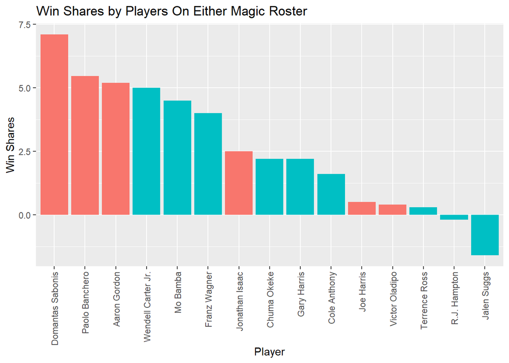

```r
combined = rbind(most_played_magic, magic_new)
combined = cbind(combined, original_team)
temp = data.table(combined)
combined = unique(temp, by = 'namePlayer')

ggplot(combined, aes(x=reorder(namePlayer, -ratioWS), y=ratioWS, fill=original_team)) +
  geom_bar(stat="identity") +
  theme(legend.position = "none", axis.text.x = element_text(angle = 90, vjust = 0.5, hjust=1)) +
  ggtitle("Win Shares by Players On Either Magic Roster") +
  labs(y="Win Shares", x = "Player")
```

Yeah… The Magic get 4 way better players, but still don’t improve too too much as Oladipo barely played last year, Joe Harris only shoots threes, and Jalen Suggs was as valuable as **4 Anthony Bennetts.**

Final verdict: Better. Not wayyyy better but definitely not slightly better.

## Hornets

**PG: LaMelo Ball** (Hornets)  
**SG: Shai Gilgeous-Alexander** (Thunder)  
**SF: Tobias Harris** (76ers)  
**PF: Bol Bol** (Magic)  
**C: Jusuf Nurkic** (Blazers)  
6: PJ Washington (Hornets)  
7: Malik Monk (Kings)  
8: Jae Crowder (Suns)  
9: Patrick Beverley (Lakers)

Extra Players:  
- Caleb Martin (Heat)  
- James Bouknight (Hornets)  
- Jalen Duren (Pistons)  
- Kemba Walker (Mavs)  
- Dwight Powell (Mavs)  
- Jarred Vanderbilt (Jazz)

LeGM is certified way better than JorBum now. He actually killed the Hornets. This team would eaily be a top 5 team. An MVP + LaMelo with a goodass frontcourt with lots of size would save families. Especially one with a killer ass bench.

Let’s see if the stats agree (this is foreshadowing)

```r
hornets <- players_2022[grepl("CHO", players_2022$slugTeamsBREF),]
most_played_hornets <- tail(hornets[order(hornets$minutesTotals),], 9)

hornets_new = rbind(players_2022[grepl("LaMelo Ball", players_2022$namePlayer),],
                    players_2022[grepl("Shai Gilgeous-Alexander", players_2022$namePlayer),],
                    players_2022[grepl("Tobias Harris", players_2022$namePlayer),],
                    players_2022[grepl("Bol Bol", players_2022$namePlayer),],
                    players_2022[grepl("Jusuf Nurkic", players_2022$namePlayer),],
                    players_2022[grepl("P.J. Washington", players_2022$namePlayer),],
                    players_2022[grepl("Malik Monk", players_2022$namePlayer),],
                    players_2022[grepl("Jae Crowder", players_2022$namePlayer),],
                    players_2022[grepl("Patrick Beverley", players_2022$namePlayer),])

wins_data_hornets = data.frame (
  Team = c("Original", "New", "Difference"),
  Wins = c(sum(most_played_hornets$ratioWS), sum(hornets_new$ratioWS), sum(hornets_new$ratioWS) - sum(most_played_hornets$ratioWS)))

kable(wins_data_hornets)
```

| Team | Wins |
| --- | --- |
| Original | 44.3 |
| New | 35.1 |
| Difference | -9.2 |

Oh. Let’s see the player stats.

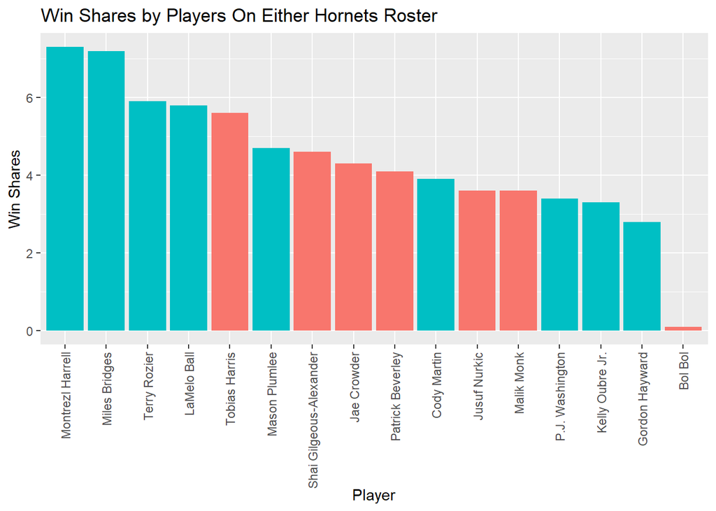

```r
combined = rbind(most_played_hornets, hornets_new)
combined = cbind(combined, original_team)
temp = data.table(combined)
combined = unique(temp, by = 'namePlayer')

ggplot(combined, aes(x=reorder(namePlayer, -ratioWS), y=ratioWS, fill=original_team)) +
  geom_bar(stat="identity") +
  theme(legend.position = "none", axis.text.x = element_text(angle = 90, vjust = 0.5, hjust=1)) +
  ggtitle("Win Shares by Players On Either Hornets Roster") +
  labs(y="Win Shares", x = "Player")
```

## Pistons

**PG: Cade Cunningham** (Pistons)  
**SG: Spencer Dinwiddie** (Mavs)  
**SF: Khris Middleton** (Bucks)  
**PF: Andre Drummond** (Bulls)  
**C: Thomas Bryant** (Lakers)  
6: Jaden Ivey (Pistons)  
7: Kentavious Caldwell-Pope (Nuggets)  
8: Bruce Brown (Nuggets)  
9: Killian Hayes (Pistons)

Extra Players:  
- Luke Kennard (Clippers)  
- Anthony Lamb (Warriors)  
- Jaremiah Robinson-Earl (Thunder)

Jaden Ivey + Cade + Middleton is nice but they have one of the most atrocious backcourts ever. Neither Drummond nor Thomas Bryant should ever be starting yet alone both of them. Just because of that they’re tank worthy in my opinion.

```r
pistons <- players_2022[grepl("DET", players_2022$slugTeamsBREF),]
most_played_pistons <- tail(pistons[order(pistons$minutesTotals),], 9)
```

```r
pistons_new = rbind(players_2022[grepl("Cade Cunningham", players_2022$namePlayer),],
                    players_2022[grepl("Spencer Dinwiddie", players_2022$namePlayer),],
                    players_2022[grepl("Khris Middleton", players_2022$namePlayer),],
                    players_2022[grepl("Andre Drummond", players_2022$namePlayer),],
                    players_2022[grepl("Thomas Bryant", players_2022$namePlayer),],
                    temp,
                    players_2022[grepl("Kentavious Caldwell-Pope", players_2022$namePlayer),],
                    players_2022[grepl("Bruce Brown", players_2022$namePlayer),],
                    players_2022[grepl("Killian Hayes", players_2022$namePlayer),])

wins_data_pistons = data.frame (
  Team = c("Original", "New", "Difference"),
  Wins = c(sum(most_played_pistons$ratioWS), sum(pistons_new$ratioWS), sum(pistons_new$ratioWS) - sum(most_played_pistons$ratioWS)))

kable(wins_data_pistons)
```

| Team | Wins |
| --- | --- |
| Original | 18.5 |
| New | 23.2 |
| Difference | 4.7 |

Yeah, slightly better but still trash, I don’t really know what to say so let’s see the players.

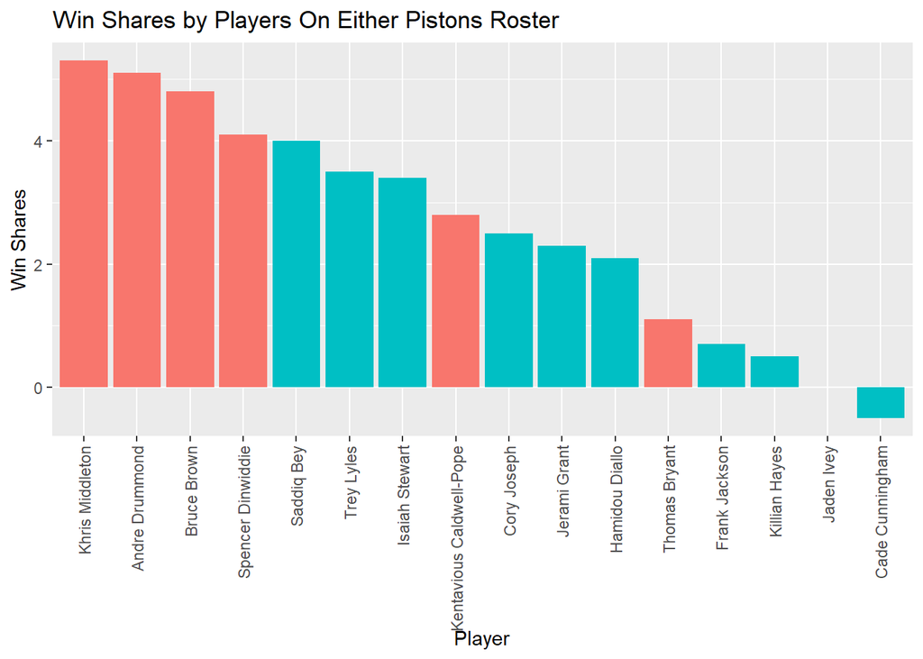

```r
combined = rbind(most_played_pistons, pistons_new)
combined = cbind(combined, original_team)
temp = data.table(combined)
combined = unique(temp, by = 'namePlayer')

ggplot(combined, aes(x=reorder(namePlayer, -ratioWS), y=ratioWS, fill=original_team)) +
  geom_bar(stat="identity") +
  theme(legend.position = "none", axis.text.x = element_text(angle = 90, vjust = 0.5, hjust=1)) +
  ggtitle("Win Shares by Players On Either Pistons Roster") +
  labs(y="Win Shares", x = "Player")
```

Shout-outs to 6th man god Drummond proving me wrong, but the 4 upgrades weren’t good enough to add too many wins. It’s also weird to see Ivey in the same section as Cade there with negative WS, but that’s fairly common among rookies.

Final verdict: I guess slightly better but still trash.

## Pelicans

**PG: Chris Paul** (Suns)  
**SG: Buddy Hield** (Pacers)  
**SF: Naji Marshall** (Pels)  
**PF: Zion Williamson** (Pels)  
**C: Anthony Davis** (Lakers)  
6: Jose Alvarado (Pels)  
7: Zach Collins (Spurs)  
8: Nick Richards (Hornets)  
9: Ziaire Williams (Grizzlies)

Extra Players:  
- Kenrich Williams (Thunder)

Not great depth, but CP3, AD, and Zion is a Big 3 I never thought of but now one I want to see the most. They need better wing help but have good shooting depth too that supplements that insane core.

Stats may say worse though given the big 3 is an old-ass, a fat-ass, and a cripple.

```r
pels <- players_2022[grepl("NOP", players_2022$slugTeamsBREF),]
most_played_pels <- tail(pels[order(pels$minutesTotals),], 9)
```

```r
pels_new = rbind(players_2022[grepl("Chris Paul", players_2022$namePlayer),],
                    players_2022[grepl("Buddy Hield", players_2022$namePlayer),],
                    players_2022[grepl("Naji Marshall", players_2022$namePlayer),],
                    temp,
                    players_2022[grepl("Anthony Davis", players_2022$namePlayer),],
                    players_2022[grepl("Jose Alvarado", players_2022$namePlayer),],
                    players_2022[grepl("Zach Collins", players_2022$namePlayer),],
                    players_2022[grepl("Nick Richards", players_2022$namePlayer),],
                    players_2022[grepl("Ziaire Williams", players_2022$namePlayer),])

wins_data_pels = data.frame (
  Team = c("Original", "New", "Difference"),
  Wins = c(sum(most_played_pels$ratioWS), sum(pels_new$ratioWS), sum(pels_new$ratioWS) - sum(most_played_pels$ratioWS)))

kable(wins_data_pels)
```

| Team | Wins |
| --- | --- |
| Original | 32.6 |
| New | 35.4 |
| Difference | 2.8 |

Yeah, not surprised by it being similar, AD probably had barely any win shares.

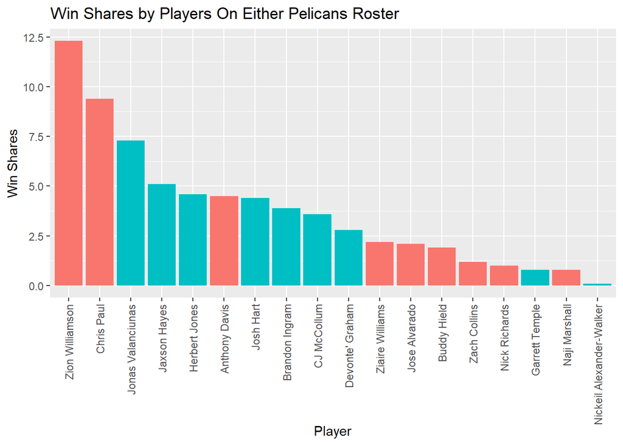

```r
combined = rbind(most_played_pels, pels_new)
combined = cbind(combined, original_team)
temp = data.table(combined)
combined = unique(temp, by = 'namePlayer')

ggplot(combined, aes(x=reorder(namePlayer, -ratioWS), y=ratioWS, fill=original_team)) +
  geom_bar(stat="identity") +
  theme(legend.position = "none", axis.text.x = element_text(angle = 90, vjust = 0.5, hjust=1)) +
  ggtitle("Win Shares by Players On Either Pelicans Roster") +
  labs(y="Win Shares", x = "Player")
```

Yeah… they get saved by Zion’s crazy high win shares and kinda exposing a flaw in my calculations, but I’ll get to that later. I feel like a hurt AD kinda compensates and balances it out a bit.

Final verdict: Around the same maybe *slightly* better. I think at each team’s peak the new one wins but you have 3 frail/falling off so I have no clue how often that can happen.

## Grizzlies

**PG: Ja Morant** (Grizzlies)  
**SG: Kyle Lowry** (Heat)  
**SF: Yuta Watanabe** (Nets)  
**PF: Trey Murphy III** (Pels)  
**C: Jaren Jackson Jr.** (Grizzlies)  
6: Mike Conley (Jazz)  
7: John Konchar (Grizzlies)  
8: Daniel Gafford (Wizards)  
9: Kevin Love (Cavs)

Extra Players:  
- Aaron Nesmith (Pacers)  
- Jevon Carter (Bucks)

Even though the Grizzlies are young, they traded for a lot of that young talent. Maybe old-ass Kyle Lowry and Kevin Love can make up for those lost players…

```r
grizzlies <- players_2022[grepl("MEM", players_2022$slugTeamsBREF),]
most_played_grizzlies <- tail(grizzlies[order(grizzlies$minutesTotals),], 9)

grizzlies_new = rbind(players_2022[grepl("Ja Morant", players_2022$namePlayer),],
                    players_2022[grepl("Kyle Lowry", players_2022$namePlayer),],
                    players_2022[grepl("Yuta Watanabe", players_2022$namePlayer),],
                    players_2022[grepl("Trey Murphy III", players_2022$namePlayer),],
                    players_2022[grepl("Jaren Jackson Jr.", players_2022$namePlayer),],
                    players_2022[grepl("Mike Conley", players_2022$namePlayer),],
                    players_2022[grepl("John Konchar", players_2022$namePlayer),],
                    players_2022[grepl("Daniel Gafford", players_2022$namePlayer),],
                    players_2022[grepl("Kevin Love", players_2022$namePlayer),])

wins_data_grizzlies = data.frame (
  Team = c("Original", "New", "Difference"),
  Wins = c(sum(most_played_grizzlies$ratioWS), sum(grizzlies_new$ratioWS), sum(grizzlies_new$ratioWS) - sum(most_played_grizzlies$ratioWS)))

kable(wins_data_grizzlies)
```

| Team | Wins |
| --- | --- |
| Original | 44.8 |
| New | 43.7 |
| Difference | -1.1 |

Hey, around the same isn’t bad, but let’s really see *why.*

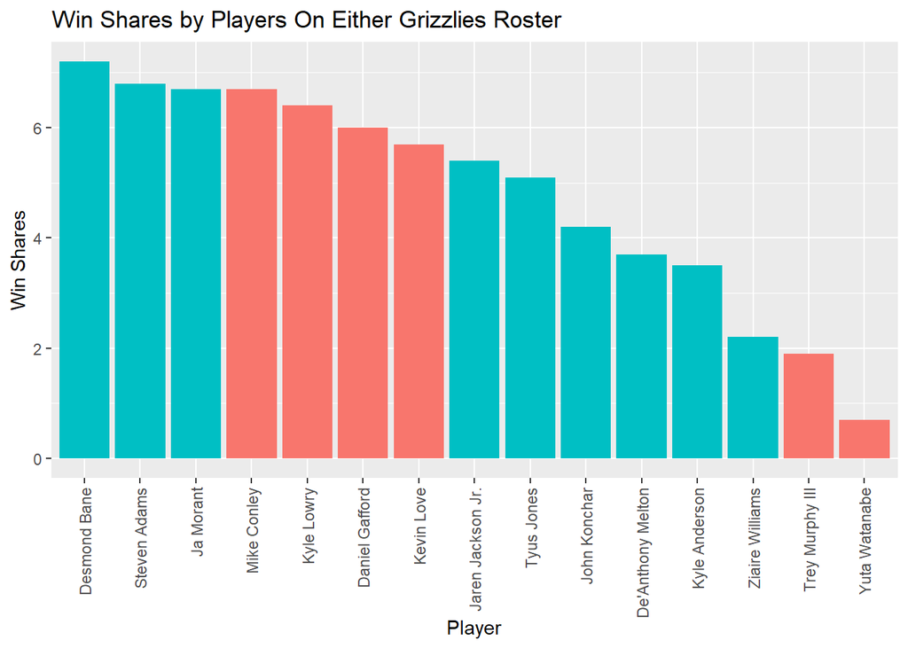

```r
combined = rbind(most_played_grizzlies, grizzlies_new)
combined = cbind(combined, original_team)
temp = data.table(combined)
combined = unique(temp, by = 'namePlayer')

ggplot(combined, aes(x=reorder(namePlayer, -ratioWS), y=ratioWS, fill=original_team)) +
  geom_bar(stat="identity") +
  theme(legend.position = "none", axis.text.x = element_text(angle = 90, vjust = 0.5, hjust=1)) +
  ggtitle("Win Shares by Players On Either Grizzlies Roster") +
  labs(y="Win Shares", x = "Player")
```

The retirees did help. Even without Bane or Adams, Conley, Lowry, Gafford, and Love provided a decent enough depth boost to make the team around the same, and that’s even without this year’s Yuta.

Final verdict: Around the same, maybe very slightly worse.

## Nuggets

**PG: Bones Hyland** (Nuggets)  
**SG: Donovan Mitchell** (Cavs)  
**SF: Michael Porter Jr.** (Nuggets)  
**PF: Nikola Jokic** (Nuggets)  
**C: Rudy Gobert** (Wolves)  
6: Jakob Poeltl (Spurs)  
7: Immanuel Quickley (Knicks)  
8: Isaiah Hartenstein (Knicks)  
9: Patty Mills (Nets)

Extra Players:  
- Evan Fournier (Knicks)  
- Torrey Craig (Suns)  
- Aaron Wiggins (Thunder)  
- Doug McDermott (Spurs)

This team shouldn’t be fair. You take the Nuggets core and replace Jamal Murray with the old Jazz core. You take the T-Wolves experiment and make it way better.

Stats will probably agree with me too:

```r
nuggets <- players_2022[grepl("DEN", players_2022$slugTeamsBREF),]
most_played_nuggets <- tail(nuggets[order(nuggets$minutesTotals),], 9)

nuggets_new = rbind(players_2022[grepl("Bones Hyland", players_2022$namePlayer),],
                    players_2022[grepl("Donovan Mitchell", players_2022$namePlayer),],
                    players_2022[grepl("Michael Porter Jr.", players_2022$namePlayer),],
                    players_2022[grepl("Nikola Jokic", players_2022$namePlayer),],
                    players_2022[grepl("Rudy Gobert", players_2022$namePlayer),],
                    players_2022[grepl("Jakob Poeltl", players_2022$namePlayer),],
                    players_2022[grepl("Immanuel Quickley", players_2022$namePlayer),],
                    players_2022[grepl("Isaiah Hartenstein", players_2022$namePlayer),],
                    players_2022[grepl("Patty Mills", players_2022$namePlayer),])

wins_data_nuggets = data.frame (
  Team = c("Original", "New", "Difference"),
  Wins = c(sum(most_played_nuggets$ratioWS), sum(nuggets_new$ratioWS), sum(nuggets_new$ratioWS) - sum(most_played_nuggets$ratioWS)))

kable(wins_data_nuggets)
```

| Team | Wins |
| --- | --- |
| Original | 39.9 |
| New | 55.7 |
| Difference | 15.8 |

Yeah. WOW. You take a solid to pretty mid team and suddenly make them the best team in the NBA. This isn’t even factoring in that MPJ barely played last year, and therefore has no value.

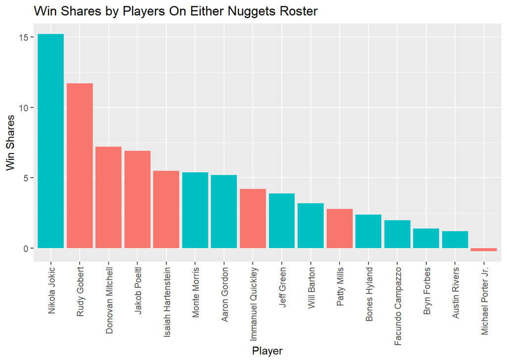

```r
combined = rbind(most_played_nuggets, nuggets_new)
combined = cbind(combined, original_team)
temp = data.table(combined)
combined = unique(temp, by = 'namePlayer')

ggplot(combined, aes(x=reorder(namePlayer, -ratioWS), y=ratioWS, fill=original_team)) +
  geom_bar(stat="identity") +
  theme(legend.position = "none", axis.text.x = element_text(angle = 90, vjust = 0.5, hjust=1)) +
  ggtitle("Win Shares by Players On Either Nuggets Roster") +
  labs(y="Win Shares", x = "Player")
```

A lot of the best players are either new or on both teams, so yeah this improvement makes sense.

Final verdict: WAY BETTER GODDAMN.

## Suns

**PG:**  
**SG: Devin Booker** (Suns)  
**SF: TJ Warren** (Nets)  
**PF: Jalen Smith** (Pacers)  
**C: Deandre Ayton** (Suns)  
6:  
7:  
8:  
9:

Easily the team most carried by trades. Only having 4 people is very funny.

Over-under at 30 less wins take you’re bets now.

```r
suns <- players_2022[grepl("PHO", players_2022$slugTeamsBREF),]
most_played_suns <- tail(suns[order(suns$minutesTotals),], 9)
```

```r
suns_new = rbind(players_2022[grepl("Devin Booker", players_2022$namePlayer),],
                    players_2022[grepl("Jalen Smith", players_2022$namePlayer),],
                    players_2022[grepl("Deandre Ayton", players_2022$namePlayer),],
                    temp,
                    goat,
                    goat,
                    goat,
                    goat,
                    goat)

wins_data_suns = data.frame (
  Team = c("Original", "New", "Difference"),
  Wins = c(sum(most_played_suns$ratioWS), sum(suns_new$ratioWS), sum(suns_new$ratioWS) - sum(most_played_suns$ratioWS)))

kable(wins_data_suns)
```

| Team | Wins |
| --- | --- |
| Original | 49.90000 |
| New | 20.38571 |
| Difference | -29.51429 |

LMAO. I even overinflated TJ Warren’s win shares and still that low. Sorry for anyone who took the over though as I rigged it.

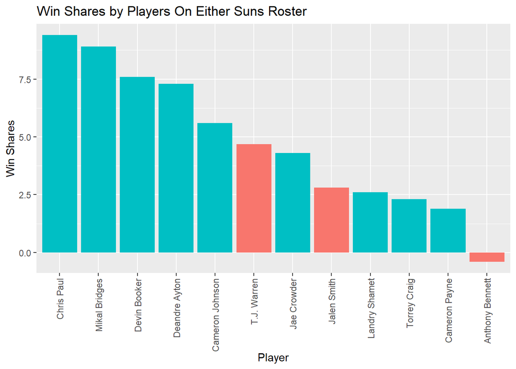

```r
combined = rbind(most_played_suns, suns_new)
combined = cbind(combined, original_team)
temp = data.table(combined)
combined = unique(temp, by = 'namePlayer')

ggplot(combined, aes(x=reorder(namePlayer, -ratioWS), y=ratioWS, fill=original_team)) +
  geom_bar(stat="identity") +
  theme(legend.position = "none", axis.text.x = element_text(angle = 90, vjust = 0.5, hjust=1)) +
  ggtitle("Win Shares by Players On Either Suns Roster") +
  labs(y="Win Shares", x = "Player")
```

Shout-out to Mikal Bridges for being for valuable than D-Book it really adds to my hate propaganda.

Final verdict: RIP BOZO

## Kings

**PG: Tyrese Haliburton** (Pacers)  
**SG: Gary Trent Jr.** (Raptors)  
**SF: Jayson Tatum** (Celtics)  
**PF: Keegan Murray** (Kings)  
**C: Wenyen Gabriel** (Lakers)  
6: Marvin Bagley III (Pistons)  
7: Davion Mitchell (Kings)  
8: Gabe Vincent (Heat)  
9: Romeo Langford (Spurs)

I love how the 2 best players on this team are players/picks they traded, as the originally drafted Kings players like Bagley are shit. This roster is also funny because looking at the first 3 names you’d think they’d be way better, but that thought fades away the longer you read.

```r
kings <- players_2022[grepl("SAC", players_2022$slugTeamsBREF),]
most_played_kings <- tail(kings[order(kings$minutesTotals),], 9)
```

```r
kings_new = rbind(players_2022[grepl("Tyrese Haliburton", players_2022$namePlayer),],
                    players_2022[grepl("Gary Trent Jr.", players_2022$namePlayer),],
                    players_2022[grepl("Jayson Tatum", players_2022$namePlayer),],
                    temp,
                    players_2022[grepl("Wenyen Gabriel", players_2022$namePlayer),],
                    players_2022[grepl("Marvin Bagley III", players_2022$namePlayer),],
                    players_2022[grepl("Davion Mitchell", players_2022$namePlayer),],
                    players_2022[grepl("Gabe Vincent", players_2022$namePlayer),],
                    players_2022[grepl("Romeo Langford", players_2022$namePlayer),])

wins_data_kings = data.frame (
  Team = c("Original", "New", "Difference"),
  Wins = c(sum(most_played_kings$ratioWS), sum(kings_new$ratioWS), sum(kings_new$ratioWS) - sum(most_played_kings$ratioWS)))

kable(wins_data_kings)
```

| Team | Wins |
| --- | --- |
| Original | 31.0000000 |
| New | 30.6923077 |
| Difference | -0.3076923 |

Yup, it faded away, let’s see how cooked that “bench” is.

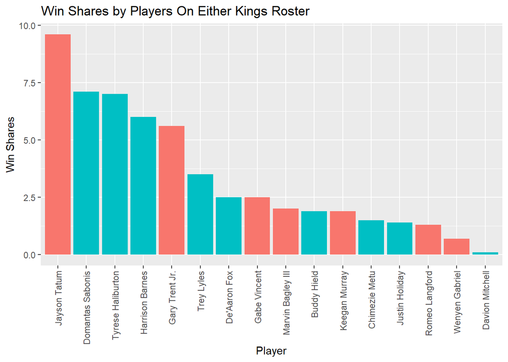

```r
combined = rbind(most_played_kings, kings_new)
combined = cbind(combined, original_team)
temp = data.table(combined)
combined = unique(temp, by = 'namePlayer')

ggplot(combined, aes(x=reorder(namePlayer, -ratioWS), y=ratioWS, fill=original_team)) +
  geom_bar(stat="identity") +
  theme(legend.position = "none", axis.text.x = element_text(angle = 90, vjust = 0.5, hjust=1)) +
  ggtitle("Win Shares by Players On Either Kings Roster") +
  labs(y="Win Shares", x = "Player")
```

Yeah… Just a 3 man show carried especially by Tatum with absolutely no depth at all.

Final verdict: Around the same.

## Trailblazers

**PG: Anfernee Simons** (Blazers)  
**SG: CJ McCollum** (Pels)  
**SF: Dillon Brooks** (Grizzlies)  
**PF: Shaedon Sharpe** (Blazers)  
**C: Isaiah Stewart** (Pistons)  
6: Malcolm Brogdon (Celtics)  
7: Malik Beasley (Jazz)  
8: Shake Milton (76ers)  
9: Nassir Little (Blazers)

Extra Players:  
- Trendon Watford (Blazers)  
- Usman Garuba (Rockets)

Ehh pretty boring since the Blazers keep a lot of their players, just feels like an improved 2021 Blazers, which I guess isn’t very good.

```r
blazers = players_2022[grepl("POR", players_2022$slugTeamsBREF),]
most_played_blazers = tail(blazers[order(blazers$minutesTotals),], 9)
```

```r
blazers_new = rbind(players_2022[grepl("Anfernee Simons", players_2022$namePlayer),],
                    players_2022[grepl("CJ McCollum", players_2022$namePlayer),],
                    temp,
                    players_2022[grepl("Dillon Brooks", players_2022$namePlayer),],
                    players_2022[grepl("Isaiah Stewart", players_2022$namePlayer),],
                    players_2022[grepl("Malcolm Brogdon", players_2022$namePlayer),],
                    players_2022[grepl("Malik Beasley", players_2022$namePlayer),],
                    players_2022[grepl("Shake Milton", players_2022$namePlayer),],
                    players_2022[grepl("Nassir Little", players_2022$namePlayer),])

wins_data_blazers = data.frame (
  Team = c("Original", "New", "Difference"),
  Wins = c(sum(most_played_blazers$ratioWS), sum(blazers_new$ratioWS), sum(blazers_new$ratioWS) - sum(most_played_blazers$ratioWS)))

kable(wins_data_blazers)
```

| Team | Wins |
| --- | --- |
| Original | 24.100000 |
| New | 20.631034 |
| Difference | -3.468965 |

Yeah, a little worse, but let’s see why.

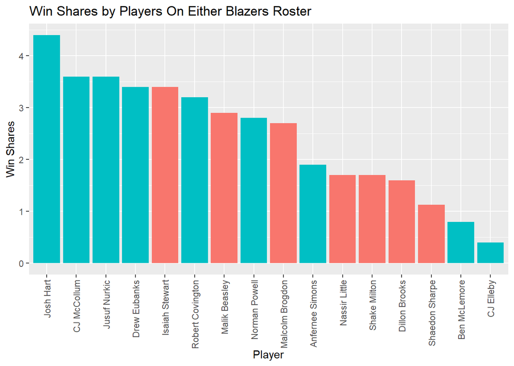

```r
combined = rbind(most_played_blazers, blazers_new)
combined = cbind(combined, original_team)
temp = data.table(combined)
combined = unique(temp, by = 'namePlayer')

ggplot(combined, aes(x=reorder(namePlayer, -ratioWS), y=ratioWS, fill=original_team)) +
  geom_bar(stat="identity") +
  theme(legend.position = "none", axis.text.x = element_text(angle = 90, vjust = 0.5, hjust=1)) +
  ggtitle("Win Shares by Players On Either Blazers Roster") +
  labs(y="Win Shares", x = "Player")
```

I had no clue Josh freaking Hart was that good, but I also think it’s that no one on this team was that useful last year. This doesn’t even include Dame, which is easily the biggest loss of this all and can easily carry the Blazers.

Final verdict: Slightly worse.

## Clippers

**PG: Kyrie Irving** (Nets)  
**SG: Eric Gordon** (Rockets)  
**SF: OG Anunoby** (Raptors)  
**PF: Blake Griffin** (Celtics)  
**C: DeAndre Jordan** (Nuggets)  
6: Reggie Bullock (Mavs)  
7: Quentin Grimes (Knicks)  
8: Terance Mann (Clippers)  
9: Jalen Williams (Thunder)

Aside from the Suns easily my favorite roster. Aside from OG Anunoby the whole starting 5 collects social security they’re so old. You’ll find them in the Uncle Drew cast in a few years (especially since Kyrie is at the 1).

```r
clippers = players_2022[grepl("LAC", players_2022$slugTeamsBREF),]
most_played_clippers = tail(clippers[order(clippers$minutesTotals),], 9)
```

```r
clippers_new = rbind(players_2022[grepl("Kyrie Irving", players_2022$namePlayer),],
                    players_2022[grepl("Eric Gordon", players_2022$namePlayer),],
                    players_2022[grepl("OG Anunoby", players_2022$namePlayer),],
                    players_2022[grepl("Blake Griffin", players_2022$namePlayer),],
                    players_2022[grepl("DeAndre Jordan", players_2022$namePlayer),],
                    players_2022[grepl("Reggie Bullock", players_2022$namePlayer),],
                    players_2022[grepl("Quentin Grimes", players_2022$namePlayer),],
                    players_2022[grepl("Terance Mann", players_2022$namePlayer),],
                    temp)

wins_data_clippers = data.frame (
  Team = c("Original", "New", "Difference"),
  Wins = c(sum(most_played_clippers$ratioWS), sum(clippers_new$ratioWS), sum(clippers_new$ratioWS) - sum(most_played_clippers$ratioWS)))

kable(wins_data_blazers)
```

[output not shown]

Yeah, a bit worse, even with how hurt the Clippers were.

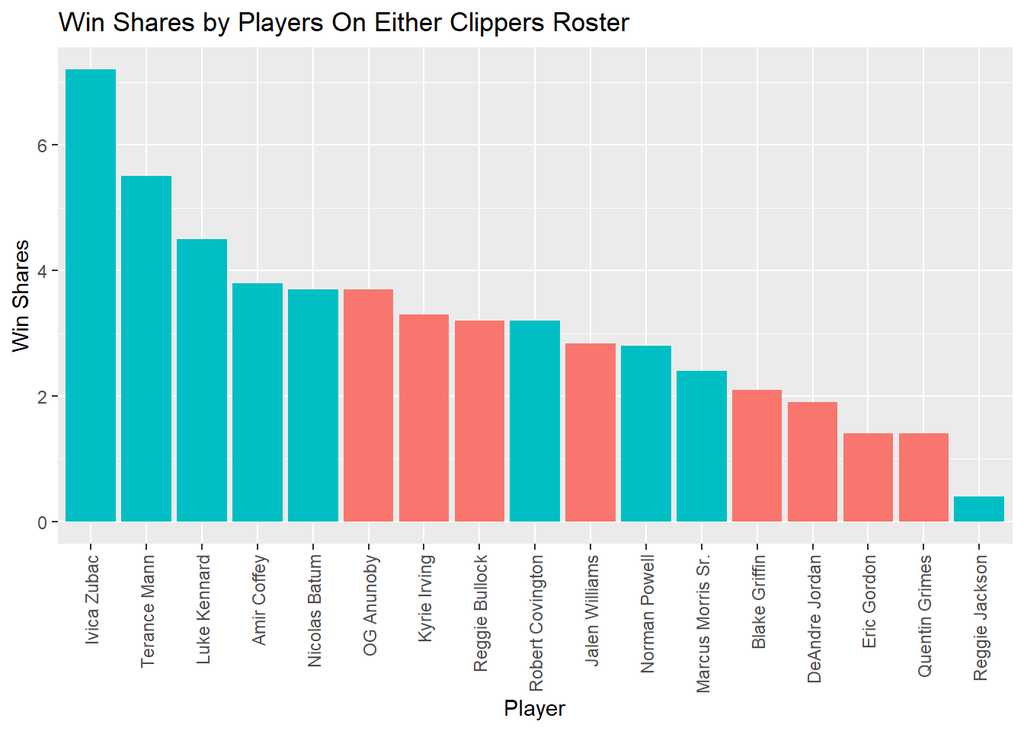

```r
combined = rbind(most_played_clippers, clippers_new)
combined = cbind(combined, original_team)
temp = data.table(combined)
combined = unique(temp, by = 'namePlayer')

ggplot(combined, aes(x=reorder(namePlayer, -ratioWS), y=ratioWS, fill=original_team)) +
  geom_bar(stat="identity") +
  theme(legend.position = "none", axis.text.x = element_text(angle = 90, vjust = 0.5, hjust=1)) +
  ggtitle("Win Shares by Players On Either Clippers Roster") +
  labs(y="Win Shares", x = "Player")
```

Yeah, PG and Kawhi not counted for regular Clips, but Kyrie missed a lot of 2022 due to vaccine issues, canceling it a *bit,* but still having Zubac as the most valuable hurts, especially with how bad Blake, DeAndre, and Eric Gordon were.

Final verdict: Worse.

## Mavericks

**PG: Trae Young** (Hawks)  
**SG: Jalen Brunson** (Knicks)  
**SF: Cam Reddish** (Knicks)  
**PF: Dorian Finney-Smith** (Mavs)  
**C: Maxi Kleber** (Mavs)  
6: Dennis Smith Jr. (Hornets)  
7: Kelly Olynyk (Jazz)  
8: Josh Green (Mavs)  
9:

Again another case of the mids. Good guards but dogshit everything else.

```r
mavs = players_2022[grepl("DAL", players_2022$slugTeamsBREF),]
most_played_mavs = tail(mavs[order(mavs$minutesTotals),], 9)

mavs_new = rbind(players_2022[grepl("Trae Young", players_2022$namePlayer),],
                    players_2022[grepl("Jalen Brunson", players_2022$namePlayer),],
                    players_2022[grepl("Cam Reddish", players_2022$namePlayer),],
                    players_2022[grepl("Dorian Finney-Smith", players_2022$namePlayer),],
                    players_2022[grepl("Maxi Kleber", players_2022$namePlayer),],
                    players_2022[grepl("Dennis Smith Jr.", players_2022$namePlayer),],
                    players_2022[grepl("Kelly Olynyk", players_2022$namePlayer),],
                    players_2022[grepl("Josh Green", players_2022$namePlayer),],
                    goat)

wins_data_mavs = data.frame (
  Team = c("Original", "New", "Difference"),
  Wins = c(sum(most_played_mavs$ratioWS), sum(mavs_new$ratioWS), sum(mavs_new$ratioWS) - sum(most_played_mavs$ratioWS)))

kable(wins_data_mavs)
```

| Team | Wins |
| --- | --- |
| Original | 47.8 |
| New | 32.1 |
| Difference | -15.7 |

The stats agree too. Even with Trae being more valuable than Luka as said before the Mavericks see considerable downgrades.

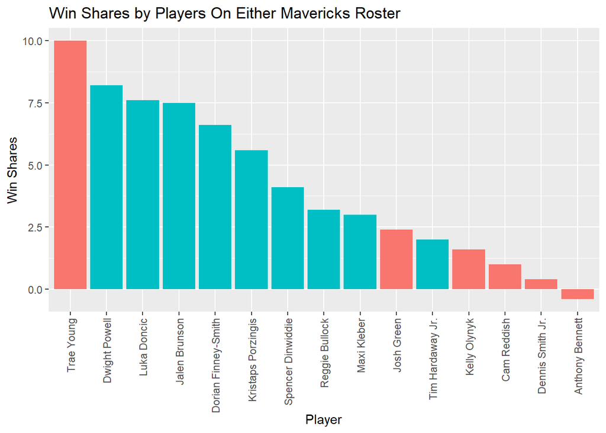

```r
combined = rbind(most_played_mavs, mavs_new)
combined = cbind(combined, original_team)
temp = data.table(combined)
combined = unique(temp, by = 'namePlayer')

ggplot(combined, aes(x=reorder(namePlayer, -ratioWS), y=ratioWS, fill=original_team)) +
  geom_bar(stat="identity") +
  theme(legend.position = "none", axis.text.x = element_text(angle = 90, vjust = 0.5, hjust=1)) +
  ggtitle("Win Shares by Players On Either Mavericks Roster") +
  labs(y="Win Shares", x = "Player")
```

Final verdict: Considerably worse.

## Warriors

**PG: Steph Curry** (Warriors)  
**SG: Jordan Poole** (Warriors)  
**SF: Klay Thompson** (Warriors)  
**PF: Harrison Barnes** (Kings)  
**C: Kevon Looney** (Warriors)  
6: Seth Curry (Nets)  
7: Chris Boucher (Raptors)  
8: Josh Hart (Blazers)  
9: James Wiseman (Warriors)

Extra Players:  
- Moses Moody (Warriors)  
- Kendrick Nunn (Lakers)

This team is very funny. Only guards and more specifically only shooters. I also like how the Poole-Draymond beef was just settled naturally here. You also get the splash quartet of Curry-Poole-Klay-Curry.

Let’s see if it actually puts wins on the court:

```r
warriors = players_2022[grepl("GSW", players_2022$slugTeamsBREF),]
most_played_warriors = tail(warriors[order(warriors$minutesTotals),], 9)
```

```r
warriors_new = rbind(players_2022[grepl("Stephen Curry", players_2022$namePlayer),],
                    players_2022[grepl("Jordan Poole", players_2022$namePlayer),],
                    players_2022[grepl("Klay Thompson", players_2022$namePlayer),],
                    players_2022[grepl("Harrison Barnes", players_2022$namePlayer),],
                    players_2022[grepl("Kevon Looney", players_2022$namePlayer),],
                    players_2022[grepl("Seth Curry", players_2022$namePlayer),],
                    players_2022[grepl("Chris Boucher", players_2022$namePlayer),],
                    players_2022[grepl("Josh Hart", players_2022$namePlayer),],
                    temp)

wins_data_warriors = data.frame (
  Team = c("Original", "New", "Difference"),
  Wins = c(sum(most_played_warriors$ratioWS), sum(warriors_new$ratioWS), sum(warriors_new$ratioWS) - sum(most_played_warriors$ratioWS)))

kable(wins_data_warriors)
```

| Team | Wins |
| --- | --- |
| Original | 45.3000000 |
| New | 45.5428571 |
| Difference | 0.2428571 |

Somehow, the exact same, so let’s see why.

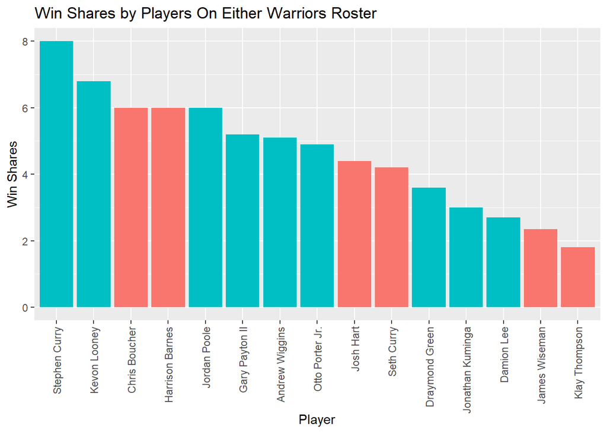

```r
combined = rbind(most_played_warriors, warriors_new)
combined = cbind(combined, original_team)
temp = data.table(combined)
combined = unique(temp, by = 'namePlayer')

ggplot(combined, aes(x=reorder(namePlayer, -ratioWS), y=ratioWS, fill=original_team)) +
  geom_bar(stat="identity") +
  theme(legend.position = "none", axis.text.x = element_text(angle = 90, vjust = 0.5, hjust=1)) +
  ggtitle("Win Shares by Players On Either Warriors Roster") +
  labs(y="Win Shares", x = "Player")
```

Mainly because the Warriors don’t lose too much super valuable, and not to mention Boucher and Barnes were surpirsingly valuable. Draymond and Klay are also certified bums by the way.

Final verdict: Around the same maybe slightly worse as I feel Wiggins was a bit underrated.

## Jazz

**PG: Alec Burks** (Pistons)  
**SG: Grayson Allen** (Bucks)  
**SF: Royce O’Neale** (Nets)  
**PF: Santi Aldama** (Grizzlies)  
**C: Walker Kessler** (Jazz)  
6: Trey Lyles (Kings)  
7: Darius Bazley (Thunder)  
8: Taurean Prince (Wolves)  
9: Wesley Matthews (Bucks)

I would rather watch my local high school basketball team than whatever this “team” is. When your number one option is Grayson Allen I question your morals as a GM. This team could draft Wemby + Scoot and still probably only reach 30 wins.

Do stats agree?

```r
jazz = players_2022[grepl("UTA", players_2022$slugTeamsBREF),]
most_played_jazz = tail(jazz[order(jazz$minutesTotals),], 9)
```

```r
jazz_new = rbind(players_2022[grepl("Alec Burks", players_2022$namePlayer),],
                    players_2022[grepl("Grayson Allen", players_2022$namePlayer),],
                    players_2022[grepl("Royce O'Neale", players_2022$namePlayer),],
                    players_2022[grepl("Santi Aldama", players_2022$namePlayer),],
                    players_2022[grepl("Trey Lyles", players_2022$namePlayer),],
                    players_2022[grepl("Darius Bazley", players_2022$namePlayer),],
                    players_2022[grepl("Taurean Prince", players_2022$namePlayer),],
                    players_2022[grepl("Wesley Matthews", players_2022$namePlayer),],
                    temp)

wins_data_jazz = data.frame (
  Team = c("Original", "New", "Difference"),
  Wins = c(sum(most_played_jazz$ratioWS), sum(jazz_new$ratioWS), sum(jazz_new$ratioWS) - sum(most_played_jazz$ratioWS)))

kable(wins_data_jazz)
```

| Team | Wins |
| --- | --- |
| Original | 47.90000 |
| New | 30.73793 |
| Difference | -17.16207 |

No. The Jazz are bad but not *that* bad.

Let’s see where they benefit:

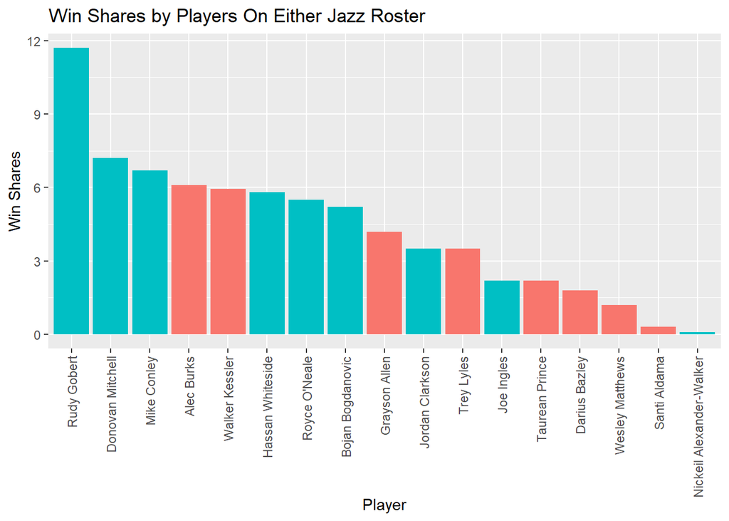

```r
combined = rbind(most_played_jazz, jazz_new)
combined = cbind(combined, original_team)
temp = data.table(combined)
combined = unique(temp, by = 'namePlayer')

ggplot(combined, aes(x=reorder(namePlayer, -ratioWS), y=ratioWS, fill=original_team)) +
  geom_bar(stat="identity") +
  theme(legend.position = "none", axis.text.x = element_text(angle = 90, vjust = 0.5, hjust=1)) +
  ggtitle("Win Shares by Players On Either Jazz Roster") +
  labs(y="Win Shares", x = "Player")
```

Looking at per-player I don’t get it either. I see this chart and expect them to be bad, but all things considered they’re not that bad.

Final verdict: Worse, just not that much worse.

## Timberwolves

**PG: Zach LaVine** (Bulls)  
**SG: Anthony Edwards** (Wolves)  
**SF: Lauri Markkanen** (Jazz)  
**PF: Bojan Bogdanovic** (Pistons)  
**C: Karl-Anthony Towns** (Wolves)  
6: Jonathan Kuminga (Warriors)  
7: Cameron Johnson (Suns)  
8: Kevin Huerter (Kings)  
9: Cedi Osman (Cavs)

Extra Players:  
- Will Barton (Wizards)  
- Naz Reid (Wolves)  
- Austin Rivers (Wolves)  
- Keita Bates-Diop (Spurs)

Dear Tim Connelly, please never fucking trade ever again. This lineup, even with Zach LaVine at the 1, would be amazing. Only 1 Center, no D-Lo issues, just good players.

Am I a dumbass?

```r
wolves = players_2022[grepl("MIN", players_2022$slugTeamsBREF),]
most_played_wolves = tail(wolves[order(wolves$minutesTotals),], 9)

wolves_new = rbind(players_2022[grepl("Zach LaVine", players_2022$namePlayer),],
                    players_2022[grepl("Anthony Edwards", players_2022$namePlayer),],
                    players_2022[grepl("Lauri Markkanen", players_2022$namePlayer),],
                    players_2022[grepl("Bojan Bogdanovic", players_2022$namePlayer),],
                    players_2022[grepl("Karl-Anthony Towns", players_2022$namePlayer),],
                    players_2022[grepl("Jonathan Kuminga", players_2022$namePlayer),],
                    players_2022[grepl("Cameron Johnson", players_2022$namePlayer),],
                    players_2022[grepl("Kevin Huerter", players_2022$namePlayer),],
                    players_2022[grepl("Cedi Osman", players_2022$namePlayer),])

wins_data_wolves = data.frame (
  Team = c("Original", "New", "Difference"),
  Wins = c(sum(most_played_wolves$ratioWS), sum(wolves_new$ratioWS), sum(wolves_new$ratioWS) - sum(most_played_wolves$ratioWS)))

kable(wins_data_wolves)
```

| Team | Wins |
| --- | --- |
| Original | 39.8 |
| New | 44.9 |
| Difference | 5.1 |

No. They’re solidly better, and this isn’t even considering how Lauri stepped up this season comapred to last.

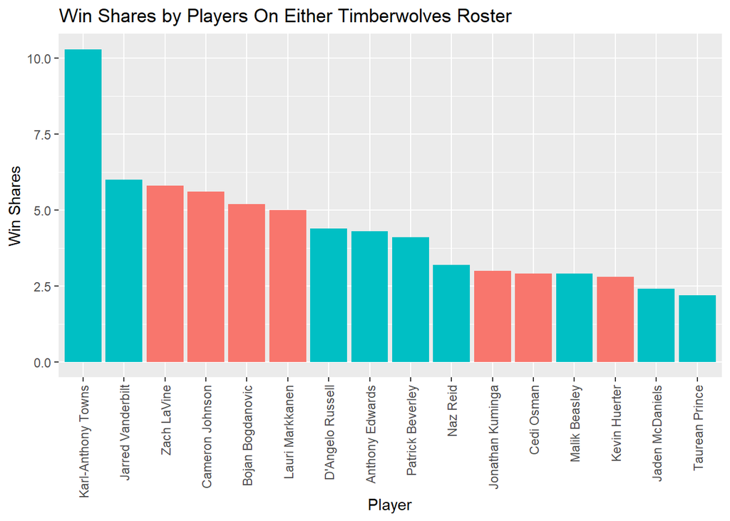

```r
combined = rbind(most_played_wolves, wolves_new)
combined = cbind(combined, original_team)
temp = data.table(combined)
combined = unique(temp, by = 'namePlayer')

ggplot(combined, aes(x=reorder(namePlayer, -ratioWS), y=ratioWS, fill=original_team)) +
  geom_bar(stat="identity") +
  theme(legend.position = "none", axis.text.x = element_text(angle = 90, vjust = 0.5, hjust=1)) +
  ggtitle("Win Shares by Players On Either Timberwolves Roster") +
  labs(y="Win Shares", x = "Player")
```

Somehow Jarred Vanderbilt was the biggest lost, but that loss was easily recouped.

Final verdict: Solidly better.

## Lakers

**PG: Lonzo Ball** (Bulls)  
**SG: Mikal Bridges** (Suns)  
**SF: Brandon Ingram** (Pels)  
**PF: Julius Randle** (Knicks)  
**C: Ivica Zubac** (Clippers)  
6: D’Angelo Russell (Wolves)  
7: De’Andre Hunter (Hawks)  
8: Austin Reaves (Lakers)  
9: Jaden McDaniels (Wolves)

Extra Players:  
- Dyson Daniels (Pels)

The Lakers went from one version of a play-in team (only stars no depth) to a different version of a play-in team (all depth no stars). The starting 5 initially looks really good until you realize either Brandon Ingram or Julius Randle are your number one option…

Let’s see if the stats have a solid opinion

```r
lakers = players_2022[grepl("LAL", players_2022$slugTeamsBREF),]
most_played_lakers = tail(lakers[order(lakers$minutesTotals),], 9)

lakers_new = rbind(players_2022[grepl("Lonzo Ball", players_2022$namePlayer),],
                    players_2022[grepl("Mikal Bridges", players_2022$namePlayer),],
                    players_2022[grepl("Brandon Ingram", players_2022$namePlayer),],
                    players_2022[grepl("Julius Randle", players_2022$namePlayer),],
                    players_2022[grepl("Ivica Zubac", players_2022$namePlayer),],
                    players_2022[grepl("D'Angelo Russell", players_2022$namePlayer),],
                    players_2022[grepl("De'Andre Hunter", players_2022$namePlayer),],
                    players_2022[grepl("Austin Reaves", players_2022$namePlayer),],
                    players_2022[grepl("Jaden McDaniels", players_2022$namePlayer),])

wins_data_lakers = data.frame (
  Team = c("Original", "New", "Difference"),
  Wins = c(sum(most_played_lakers$ratioWS), sum(lakers_new$ratioWS), sum(lakers_new$ratioWS) - sum(most_played_lakers$ratioWS)))

kable(wins_data_lakers)
```

| Team | Wins |
| --- | --- |
| Original | 27.9 |
| New | 36.1 |
| Difference | 8.2 |

The Lakers are better by a good margin.

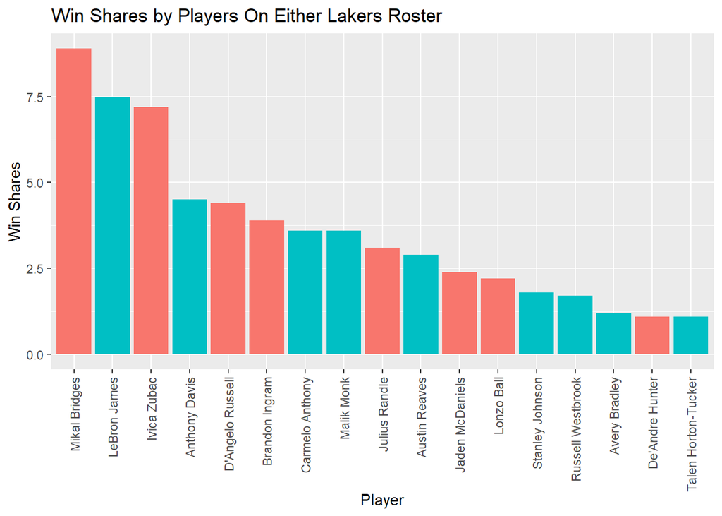

```r
combined = rbind(most_played_lakers, lakers_new)
combined = cbind(combined, original_team)
temp = data.table(combined)
combined = unique(temp, by = 'namePlayer')

ggplot(combined, aes(x=reorder(namePlayer, -ratioWS), y=ratioWS, fill=original_team)) +
  geom_bar(stat="identity") +
  theme(legend.position = "none", axis.text.x = element_text(angle = 90, vjust = 0.5, hjust=1)) +
  ggtitle("Win Shares by Players On Either Lakers Roster") +
  labs(y="Win Shares", x = "Player")
```

This chart is funny because it shows how bad Westbrick was last year where essentially anyone was more valuable.

Final verdict: Improved, espcially considering the future.